# Public perceptions on human health risks of climate change in Cyprus: 2018 and 2021 survey results

Corina Konstantinou-Christina Xeni

August 2022

The script was prepared for the statistical analysis of the data collected from the online survey, with the aim to explore the Cypriot perceptions regarding climate-related health risks in 2018 and 2021. The tables in SI and MS do not appear in the order they appear in the output and in some cases the output tables were merged.

### Table 1 - Demographic characteristics - Study participants

|  | 2018 | 2021 | p | test |
| --- | --- | --- | --- | --- |
| n | 185 | 202 |  |  |
| sex (%) |  |  | 0.233 |  |
| Female | 101 (54.6) | 124 (61.4) |  |  |
| Male | 84 (45.4) | 77 (38.1) |  |  |
| Prefer not to say | 0 ( 0.0) | 1 ( 0.5) |  |  |
| age_cat (%) |  |  | 0.002 |  |
| 18-34 | 69 (37.3) | 98 (48.5) |  |  |
| 35-54 | 76 (41.1) | 85 (42.1) |  |  |
| >54 | 40 (21.6) | 19 ( 9.4) |  |  |
| place_of_birth (%) |  |  | 0.069 |  |
| Large city | 97 (52.4) | 118 (58.4) |  |  |
| Suburb near large city | 29 (15.7) | 17 ( 8.4) |  |  |
| Small city | 35 (18.9) | 31 (15.3) |  |  |
| Rural | 24 (13.0) | 36 (17.8) |  |  |
| education_level (%) |  |  | 0.029 |  |
| I have never been to school | 1 ( 0.5) | 1 ( 0.5) |  |  |
| High School/ Vocational High School (diploma) | 19 (10.3) | 21 (10.4) |  |  |
| Higher (after high school) non-tertiary Education | 0 ( 0.0) | 8 ( 4.0) |  |  |
| Higher Tertiary Education (non-university) | 13 ( 7.0) | 10 ( 5.0) |  |  |
| University (Bachelor degree) | 37 (20.0) | 59 (29.2) |  |  |
| University- Postgraduate (Master’s Degree) | 76 (41.1) | 73 (36.1) |  |  |
| PhD | 39 (21.1) | 30 (14.9) |  |  |
| occupational_status (%) |  |  | 0.001 |  |
| Employed/ self-employed | 143 (77.3) | 145 (71.8) |  |  |
| Retired | 18 ( 9.7) | 5 ( 2.5) |  |  |
| Student | 18 ( 9.7) | 30 (14.9) |  |  |
| Unemployed/ Out of employment | 5 ( 2.7) | 20 ( 9.9) |  |  |
| Housekeeping | 1 ( 0.5) | 2 ( 1.0) |  |  |
| district (%) |  |  | 0.398 |  |
| Paphos | 19 (10.3) | 10 ( 5.0) |  |  |
| Limassol | 81 (43.8) | 96 (47.5) |  |  |
| Nicosia | 70 (37.8) | 73 (36.1) |  |  |
| Famagusta | 3 ( 1.6) | 4 ( 2.0) |  |  |
| Larnaka | 11 ( 5.9) | 17 ( 8.4) |  |  |
| Other | 1 ( 0.5) | 2 ( 1.0) |  |  |
| area_discr (%) |  |  | 0.197 |  |
| Large city | 69 (37.3) | 97 (48.0) |  |  |
| Suburb near large city | 47 (25.4) | 42 (20.8) |  |  |
| Small city | 34 (18.4) | 29 (14.4) |  |  |
| Rural | 35 (18.9) | 34 (16.8) |  |  |
| rate_area (%) |  |  | 0.036 |  |
| Very good | 86 (46.5) | 67 (33.2) |  |  |
| Somewhat good | 83 (44.9) | 109 (54.0) |  |  |
| Somewhat bad | 15 ( 8.1) | 19 ( 9.4) |  |  |
| Very bad | 1 ( 0.5) | 5 ( 2.5) |  |  |
| Don’t know | 0 ( 0.0) | 2 ( 1.0) |  |  |
| marital_status (%) |  |  | 0.001 |  |
| Unmarried | 56 (30.3) | 100 (49.5) |  |  |
| Married | 109 (58.9) | 93 (46.0) |  |  |
| Divorced | 16 ( 8.6) | 7 ( 3.5) |  |  |
| Widowed | 4 ( 2.2) | 2 ( 1.0) |  |  |
| children = No (%) | 75 (40.5) | 116 (57.4) | 0.001 |  |

### Table 2 and 3 - Self-assessed health

Scales based on the RAND 36-item Health Survey

|  | Overall |
| --- | --- |
| n | 202 |
| phys_func (mean (SD)) | 92.95 (11.68) |
| phys_health (mean (SD)) | 81.31 (31.45) |
| emotion_prob (mean (SD)) | 66.50 (41.73) |
| energy_fatigue (mean (SD)) | 54.61 (19.37) |
| emotion_wellbeing (mean (SD)) | 60.42 (20.00) |
| social_func (mean (SD)) | 74.88 (22.82) |
| general_health (mean (SD)) | 70.30 (16.49) |
| health_change (mean (SD)) | 55.07 (18.88) |

|  | Overall |
| --- | --- |
| n | 202 |
| phys_func (median [IQR]) | 100.00 [90.00, 100.00] |
| phys_health (median [IQR]) | 100.00 [75.00, 100.00] |
| emotion_prob (median [IQR]) | 100.00 [33.33, 100.00] |
| energy_fatigue (median [IQR]) | 56.25 [43.75, 68.75] |
| emotion_wellbeing (median [IQR]) | 65.00 [45.00, 75.00] |
| social_func (median [IQR]) | 75.00 [62.50, 100.00] |
| general_health (median [IQR]) | 70.00 [60.00, 80.00] |
| health_change (median [IQR]) | 50.00 [50.00, 50.00] |

Cronbach’s alpha for scales:

- Physical functioning:

|  | raw_alpha | std.alpha | G6(smc) | average_r | S/N | ase | mean | sd | median_r |
| --- | --- | --- | --- | --- | --- | --- | --- | --- | --- |
|  | 0.8398336 | 0.8708658 | 0.8964307 | 0.402767 | 6.743885 | 0.0151963 | 92.94554 | 11.68032 | 0.42383 |

- Role limitations due to physical health:

|  | raw_alpha | std.alpha | G6(smc) | average_r | S/N | ase | mean | sd | median_r |
| --- | --- | --- | --- | --- | --- | --- | --- | --- | --- |
|  | 0.8235996 | 0.8262598 | 0.7825186 | 0.5431559 | 4.755721 | 0.0201848 | 81.31188 | 31.4514 | 0.5486919 |

- Role limitations due to emotional problems:

|  | raw_alpha | std.alpha | G6(smc) | average_r | S/N | ase | mean | sd | median_r |
| --- | --- | --- | --- | --- | --- | --- | --- | --- | --- |
|  | 0.8590423 | 0.8589727 | 0.8046513 | 0.669997 | 6.090827 | 0.0171723 | 66.50165 | 41.72848 | 0.6659429 |

- Energy/fatigue:

|  | raw_alpha | std.alpha | G6(smc) | average_r | S/N | ase | mean | sd | median_r |
| --- | --- | --- | --- | --- | --- | --- | --- | --- | --- |
|  | 0.79215 | 0.7931417 | 0.7850795 | 0.48942 | 3.834227 | 0.0244806 | 54.61015 | 19.37241 | 0.43148 |

- Emotional well-being:

|  | raw_alpha | std.alpha | G6(smc) | average_r | S/N | ase | mean | sd | median_r |
| --- | --- | --- | --- | --- | --- | --- | --- | --- | --- |
|  | 0.8399505 | 0.8399315 | 0.8145418 | 0.5120679 | 5.247327 | 0.017686 | 60.42079 | 20.00488 | 0.52204 |

- Social functioning:

|  | raw_alpha | std.alpha | G6(smc) | average_r | S/N | ase | mean | sd | median_r |
| --- | --- | --- | --- | --- | --- | --- | --- | --- | --- |
|  | 0.6986168 | 0.7000009 | 0.5384626 | 0.5384626 | 2.333343 | 0.0422293 | 74.87624 | 22.82144 | 0.5384626 |

- General health:

|  | raw_alpha | std.alpha | G6(smc) | average_r | S/N | ase | mean | sd | median_r |
| --- | --- | --- | --- | --- | --- | --- | --- | --- | --- |
|  | 0.7076862 | 0.7121365 | 0.6872976 | 0.3310025 | 2.473869 | 0.0319111 | 70.29703 | 16.48642 | 0.3079464 |

### Table. q_116-q_128 How reliable do you consider the following information sources to be (2021)?

| Reliability level | Extremely reliable | Quite a bit reliable | Moderately reliable | Slightly reliable | Not at all reliable |
| --- | --- | --- | --- | --- | --- |
| Social media and the Internet | 5 (2) | 33 (16) | 95 (47) | 45 (22) | 24 (12) |
| Television news | 10 (5) | 60 (30) | 79 (39) | 34 (17) | 19 (9) |
| Films and documentaries on television | 35 (17) | 97 (48) | 55 (27) | 10 (5) | 5 (2) |
| Conversations with family, friends, neighbours, etc. | 3 (1) | 22 (11) | 89 (44) | 59 (29) | 29 (14) |
| Newspapers | 8 (4) | 71 (35) | 82 (41) | 29 (14) | 12 (6) |
| Medical doctors | 53 (26) | 96 (48) | 42 (21) | 7 (3) | 4 (2) |
| Eucation/lectures/courses | 76 (38) | 94 (47) | 27 (13) | 2 (1) | 3 (1) |
| Publications, brochures or info materials | 55 (27) | 86 (43) | 48 (24) | 9 (4) | 4 (2) |
| Radio | 7 (3) | 62 (31) | 97 (48) | 26 (13) | 10 (5) |
| Magazines | 5 (2) | 46 (23) | 98 (49) | 37 (18) | 16 (8) |
| Books | 59 (29) | 103 (51) | 35 (17) | 4 (2) | 1 (0) |
| Events | 54 (27) | 103 (51) | 36 (18) | 5 (2) | 4 (2) |
| Politicians | 2 (1) | 10 (5) | 48 (24) | 62 (31) | 80 (40) |

### Table 4. Choose up to 5 ways of how you receive information regarding environmental health risks (2021)

|  | Overall |
| --- | --- |
| n | 202 |
| Social media and the Internet = Yes (%) | 162 (80.2) |
| Television news = Yes (%) | 125 (61.9) |
| Films and documentaries on television = Yes (%) | 130 (64.4) |
| Conversations with relatives, family, friends, neighbours, etc. = Yes (%) | 74 (36.6) |
| Newspapers = Yes (%) | 43 (21.3) |
| Medical doctors = Yes (%) | 43 (21.3) |
| Education/ lectures/ courses = Yes (%) | 92 (45.5) |
| Publications, brochures or information materials = Yes (%) | 55 (27.2) |
| The radio = Yes (%) | 14 ( 6.9) |
| Magazines = Yes (%) | 41 (20.3) |
| Books = Yes (%) | 61 (30.2) |
| Events (conferences, fairs, exhibitions, festivals, etc.) = Yes (%) | 10 ( 5.0) |
| Politicians = Yes (%) | 88 (43.6) |
| Other = Yes (%) | 13 ( 6.4) |

### Table 5.Choose up to 5 ways of how you would like to receive information regarding environmental health risks (2021)

|  | Overall |
| --- | --- |
| n | 202 |
| From Social media and the Internet = Yes (%) | 137 (67.8) |
| From Television news = Yes (%) | 108 (53.5) |
| From Films and documentaries on television = Yes (%) | 102 (50.5) |
| From Conversations with relatives, family, friends, neighbours, etc. = Yes (%) | 30 (14.9) |
| From Newspapers = Yes (%) | 53 (26.2) |
| From Medical doctors = Yes (%) | 76 (37.6) |
| From Education/ lectures/ courses = Yes (%) | 98 (48.5) |
| From Publications, brochures or information materials = Yes (%) | 62 (30.7) |
| From The radio = Yes (%) | 21 (10.4) |
| From Magazines = Yes (%) | 50 (24.8) |
| From Books = Yes (%) | 106 (52.5) |
| From Events (conferences, fairs, exhibitions, festivals, etc.) = Yes (%) | 22 (10.9) |
| From Politicians = Yes (%) | 108 (53.5) |
| From Other = Yes (%) | 6 ( 3.0) |

### Comparisons in 2021 by sex

### Table 6. Do you see evidence of climate change on the planet?

|  | Female | Male | p | test |
| --- | --- | --- | --- | --- |
| n | 124 | 77 |  |  |
| climate_change (%) |  |  | 0.008 |  |
| Moderately or Slightly or Not at all | 15 (12.1) | 20 (26.0) |  |  |
| Quite a bit | 39 (31.5) | 29 (37.7) |  |  |
| Extremely | 70 (56.5) | 28 (36.4) |  |  |

### Table 7. With environmental factors in mind, such as climate change, pollution and (toxic) waste, how often do you think will the following health issues occur in 2031 (in 10 years) compared to now, in Cyprus?

|  | Female | Male | p | test |
| --- | --- | --- | --- | --- |
| n | 124 | 77 |  |  |
| accidents (%) |  |  | 0.129 |  |
| Much more | 17 (13.7) | 11 (14.3) |  |  |
| Somewhat more | 49 (39.5) | 20 (26.0) |  |  |
| About the same or less | 58 (46.8) | 46 (59.7) |  |  |
| asthma_patients (%) |  |  | 0.001 |  |
| Much more | 68 (54.8) | 27 (35.1) |  |  |
| Somewhat more | 52 (41.9) | 37 (48.1) |  |  |
| About the same or less | 4 ( 3.2) | 13 (16.9) |  |  |
| cancer_patients (%) |  |  | <0.001 |  |
| Much more | 71 (57.3) | 25 (32.5) |  |  |
| Somewhat more | 47 (37.9) | 33 (42.9) |  |  |
| About the same or less | 6 ( 4.8) | 19 (24.7) |  |  |
| obese_people (%) |  |  | <0.001 |  |
| Much more | 55 (44.4) | 19 (24.7) |  |  |
| Somewhat more | 47 (37.9) | 26 (33.8) |  |  |
| About the same or less | 22 (17.7) | 32 (41.6) |  |  |
| type2_diabetes (%) |  |  | 0.001 |  |
| Much more | 49 (39.5) | 13 (16.9) |  |  |
| Somewhat more | 48 (38.7) | 34 (44.2) |  |  |
| About the same or less | 27 (21.8) | 30 (39.0) |  |  |
| hypertension_patients (%) |  |  | 0.004 |  |
| Much more | 50 (40.3) | 15 (19.5) |  |  |
| Somewhat more | 52 (41.9) | 37 (48.1) |  |  |
| About the same or less | 22 (17.7) | 25 (32.5) |  |  |
| infectious_disease (%) |  |  | 0.003 |  |
| Much more | 60 (48.4) | 22 (28.6) |  |  |
| Somewhat more | 45 (36.3) | 29 (37.7) |  |  |
| About the same or less | 19 (15.3) | 26 (33.8) |  |  |
| mental_health (%) |  |  | <0.001 |  |
| Much more | 81 (65.3) | 27 (35.1) |  |  |
| Somewhat more | 33 (26.6) | 32 (41.6) |  |  |
| About the same or less | 10 ( 8.1) | 18 (23.4) |  |  |

### Table 8. To what degree do you think that the following factors are being influenced by climate change?

|  | Female | Male | p | test |
| --- | --- | --- | --- | --- |
| n | 117 | 71 |  |  |
| increase_temp (%) |  |  | 0.028 |  |
| Extremely influenced | 98 (83.8) | 48 (67.6) |  |  |
| Quite a bit influenced | 15 (12.8) | 16 (22.5) |  |  |
| Moderately, Slightly or Not influenced | 4 ( 3.4) | 7 ( 9.9) |  |  |
| extreme_weather (%) |  |  | 0.037 |  |
| Extremely influenced | 94 (80.3) | 45 (63.4) |  |  |
| Quite a bit influenced | 17 (14.5) | 19 (26.8) |  |  |
| Moderately, Slightly or Not influenced | 6 ( 5.1) | 7 ( 9.9) |  |  |
| atmospheric_pollution (%) |  |  | <0.001 |  |
| Extremely influenced | 94 (80.3) | 31 (43.7) |  |  |
| Quite a bit influenced | 18 (15.4) | 22 (31.0) |  |  |
| Moderately, Slightly or Not influenced | 5 ( 4.3) | 18 (25.4) |  |  |
| water_pollution (%) |  |  | <0.001 |  |
| Extremely influenced | 84 (71.8) | 21 (29.6) |  |  |
| Quite a bit influenced | 24 (20.5) | 29 (40.8) |  |  |
| Moderately, Slightly or Not influenced | 9 ( 7.7) | 21 (29.6) |  |  |
| food_contamination (%) |  |  | <0.001 |  |
| Extremely influenced | 75 (64.1) | 16 (22.5) |  |  |
| Quite a bit influenced | 26 (22.2) | 31 (43.7) |  |  |
| Moderately, Slightly or Not influenced | 16 (13.7) | 24 (33.8) |  |  |
| soil_pollution (%) |  |  | <0.001 |  |
| Extremely influenced | 88 (75.2) | 21 (29.6) |  |  |
| Quite a bit influenced | 17 (14.5) | 26 (36.6) |  |  |
| Moderately, Slightly or Not influenced | 12 (10.3) | 24 (33.8) |  |  |
| radiation (%) |  |  | <0.001 |  |
| Extremely influenced | 88 (75.2) | 35 (49.3) |  |  |
| Quite a bit influenced | 22 (18.8) | 20 (28.2) |  |  |
| Moderately, Slightly or Not influenced | 7 ( 6.0) | 16 (22.5) |  |  |

### Table 9. How important do you think environmental factors are in causing diseases?

|  | Female | Male | p | test |
| --- | --- | --- | --- | --- |
| n | 124 | 77 |  |  |
| factors_affect_health (%) |  |  | 0.001 |  |
| Very important | 106 (85.5) | 49 (63.6) |  |  |
| Somewhat important | 16 (12.9) | 21 (27.3) |  |  |
| Not too important or Not at all important or Don’t know | 2 ( 1.6) | 7 ( 9.1) |  |  |

### Table 10. How dangerous do you think the following environmental exposures are for your health?

|  | Female | Male | p | test |
| --- | --- | --- | --- | --- |
| n | 124 | 77 |  |  |
| atmospheric_pollution_h (%) |  |  | <0.001 |  |
| Very serious danger | 105 (84.7) | 45 (58.4) |  |  |
| Somewhat serious danger | 18 (14.5) | 26 (33.8) |  |  |
| Somewhat minor danger or No danger at all or Don’t know | 1 ( 0.8) | 6 ( 7.8) |  |  |
| water_pollution_h (%) |  |  | <0.001 |  |
| Very serious danger | 102 (82.3) | 41 (53.2) |  |  |
| Somewhat serious danger | 20 (16.1) | 29 (37.7) |  |  |
| Somewhat minor danger or No danger at all or Don’t know | 2 ( 1.6) | 7 ( 9.1) |  |  |
| chemicals (%) |  |  | <0.001 |  |
| Very serious danger | 107 (86.3) | 49 (63.6) |  |  |
| Somewhat serious danger | 16 (12.9) | 22 (28.6) |  |  |
| Somewhat minor danger or No danger at all or Don’t know | 1 ( 0.8) | 6 ( 7.8) |  |  |
| waste (%) |  |  | <0.001 |  |
| Very serious danger | 102 (82.3) | 42 (54.5) |  |  |
| Somewhat serious danger | 17 (13.7) | 26 (33.8) |  |  |
| Somewhat minor danger or No danger at all or Don’t know | 5 ( 4.0) | 9 (11.7) |  |  |
| heatwave (%) |  |  | <0.001 |  |
| Very serious danger | 65 (52.4) | 23 (29.9) |  |  |
| Somewhat serious danger | 51 (41.1) | 30 (39.0) |  |  |
| Somewhat minor danger or No danger at all or Don’t know | 8 ( 6.5) | 24 (31.2) |  |  |
| floods (%) |  |  | <0.001 |  |
| Very serious danger | 48 (38.7) | 16 (20.8) |  |  |
| Somewhat serious danger | 55 (44.4) | 26 (33.8) |  |  |
| Somewhat minor danger or No danger at all or Don’t know | 21 (16.9) | 35 (45.5) |  |  |
| scarcity (%) |  |  | 0.002 |  |
| Very serious danger | 74 (59.7) | 32 (41.6) |  |  |
| Somewhat serious danger | 41 (33.1) | 27 (35.1) |  |  |
| Somewhat minor danger or No danger at all or Don’t know | 9 ( 7.3) | 18 (23.4) |  |  |
| rural_pollution (%) |  |  | <0.001 |  |
| Very serious danger | 87 (70.2) | 32 (41.6) |  |  |
| Somewhat serious danger | 34 (27.4) | 35 (45.5) |  |  |
| Somewhat minor danger or No danger at all or Don’t know | 3 ( 2.4) | 10 (13.0) |  |  |
| noise_pollution (%) |  |  | 0.037 |  |
| Very serious danger | 44 (35.5) | 21 (27.3) |  |  |
| Somewhat serious danger | 47 (37.9) | 22 (28.6) |  |  |
| Somewhat minor danger or No danger at all or Don’t know | 33 (26.6) | 34 (44.2) |  |  |
| consum_habits (%) |  |  | 0.026 |  |
| Very serious danger | 65 (52.4) | 26 (33.8) |  |  |
| Somewhat serious danger | 39 (31.5) | 30 (39.0) |  |  |
| Somewhat minor danger or No danger at all or Don’t know | 20 (16.1) | 21 (27.3) |  |  |
| invasive_items (%) |  |  | 0.013 |  |
| Very serious danger | 35 (28.2) | 15 (19.5) |  |  |
| Somewhat serious danger | 52 (41.9) | 23 (29.9) |  |  |
| Somewhat minor danger or No danger at all or Don’t know | 37 (29.8) | 39 (50.6) |  |  |
| depl_natural_resources (%) |  |  | 0.035 |  |
| Very serious danger | 69 (55.6) | 31 (40.3) |  |  |
| Somewhat serious danger | 42 (33.9) | 29 (37.7) |  |  |
| Somewhat minor danger or No danger at all or Don’t know | 13 (10.5) | 17 (22.1) |  |  |
| biodiversity_reduction (%) |  |  | 0.013 |  |
| Very serious danger | 67 (54.0) | 29 (37.7) |  |  |
| Somewhat serious danger | 43 (34.7) | 28 (36.4) |  |  |
| Somewhat minor danger or No danger at all or Don’t know | 14 (11.3) | 20 (26.0) |  |  |
| soil_degradation (%) |  |  | 0.011 |  |
| Very serious danger | 67 (54.0) | 26 (33.8) |  |  |
| Somewhat serious danger | 37 (29.8) | 28 (36.4) |  |  |
| Somewhat minor danger or No danger at all or Don’t know | 20 (16.1) | 23 (29.9) |  |  |
| covid (%) |  |  | 0.147 |  |
| Very serious danger | 54 (43.5) | 23 (29.9) |  |  |
| Somewhat serious danger | 38 (30.6) | 28 (36.4) |  |  |
| Somewhat minor danger or No danger at all or Don’t know | 32 (25.8) | 26 (33.8) |  |  |

### Table 11. Now thinking of some specific illnesses, do you think environmental factors play a major role,minor role or no role at all in causing the following illnesses?

|  | Female | Male | p | test |
| --- | --- | --- | --- | --- |
| n | 124 | 77 |  |  |
| cancer_child (%) |  |  | 0.024 |  |
| Major role | 96 (77.4) | 46 (59.7) |  |  |
| Minor role | 18 (14.5) | 22 (28.6) |  |  |
| No role at all or Don’t know | 10 ( 8.1) | 9 (11.7) |  |  |
| infertility (%) |  |  | 0.254 |  |
| Major role | 68 (54.8) | 33 (42.9) |  |  |
| Minor role | 35 (28.2) | 27 (35.1) |  |  |
| No role at all or Don’t know | 21 (16.9) | 17 (22.1) |  |  |
| asthma_child (%) |  |  | 0.382 |  |
| Major role | 96 (77.4) | 53 (68.8) |  |  |
| Minor role | 22 (17.7) | 18 (23.4) |  |  |
| No role at all or Don’t know | 6 ( 4.8) | 6 ( 7.8) |  |  |
| allergies (%) |  |  | 0.006 |  |
| Major role | 112 (90.3) | 60 (77.9) |  |  |
| Minor role | 12 ( 9.7) | 12 (15.6) |  |  |
| No role at all or Don’t know | 0 ( 0.0) | 5 ( 6.5) |  |  |
| genetic_abnormalities (%) |  |  | 0.007 |  |
| Major role | 74 (59.7) | 30 (39.0) |  |  |
| Minor role | 33 (26.6) | 25 (32.5) |  |  |
| No role at all or Don’t know | 17 (13.7) | 22 (28.6) |  |  |
| breast_cancer (%) |  |  | 0.001 |  |
| Major role | 73 (58.9) | 25 (32.5) |  |  |
| Minor role | 30 (24.2) | 31 (40.3) |  |  |
| No role at all or Don’t know | 21 (16.9) | 21 (27.3) |  |  |
| hypertension (%) |  |  | 0.050 |  |
| Major role | 59 (47.6) | 25 (32.5) |  |  |
| Minor role | 48 (38.7) | 33 (42.9) |  |  |
| No role at all or Don’t know | 17 (13.7) | 19 (24.7) |  |  |
| flu (%) |  |  | 0.001 |  |
| Major role | 59 (47.6) | 26 (33.8) |  |  |
| Minor role | 54 (43.5) | 29 (37.7) |  |  |
| No role at all or Don’t know | 11 ( 8.9) | 22 (28.6) |  |  |
| prostate_cancer (%) |  |  | 0.003 |  |
| Major role | 62 (50.0) | 20 (26.0) |  |  |
| Minor role | 36 (29.0) | 31 (40.3) |  |  |
| No role at all or Don’t know | 26 (21.0) | 26 (33.8) |  |  |
| brain_tumour (%) |  |  | 0.001 |  |
| Major role | 70 (56.5) | 23 (29.9) |  |  |
| Minor role | 32 (25.8) | 31 (40.3) |  |  |
| No role at all or Don’t know | 22 (17.7) | 23 (29.9) |  |  |
| asthma_adults (%) |  |  | <0.001 |  |
| Major role | 104 (83.9) | 45 (58.4) |  |  |
| Minor role | 15 (12.1) | 23 (29.9) |  |  |
| No role at all or Don’t know | 5 ( 4.0) | 9 (11.7) |  |  |
| obesity (%) |  |  | 0.004 |  |
| Major role | 62 (50.0) | 24 (31.2) |  |  |
| Minor role | 45 (36.3) | 29 (37.7) |  |  |
| No role at all or Don’t know | 17 (13.7) | 24 (31.2) |  |  |
| type_ii_diabetes (%) |  |  | 0.005 |  |
| Major role | 57 (46.0) | 19 (24.7) |  |  |
| Minor role | 43 (34.7) | 31 (40.3) |  |  |
| No role at all or Don’t know | 24 (19.4) | 27 (35.1) |  |  |
| thyroid_cancer (%) |  |  | 0.006 |  |
| Major role | 72 (58.1) | 27 (35.1) |  |  |
| Minor role | 30 (24.2) | 30 (39.0) |  |  |
| No role at all or Don’t know | 22 (17.7) | 20 (26.0) |  |  |
| vector_borne_infdis (%) |  |  | <0.001 |  |
| Major role | 80 (64.5) | 32 (41.6) |  |  |
| Minor role | 37 (29.8) | 27 (35.1) |  |  |
| No role at all or Don’t know | 7 ( 5.6) | 18 (23.4) |  |  |
| infectious_diseases_1 (%) |  |  | <0.001 |  |
| Major role | 58 (46.8) | 19 (24.7) |  |  |
| Minor role | 46 (37.1) | 28 (36.4) |  |  |
| No role at all or Don’t know | 20 (16.1) | 30 (39.0) |  |  |
| covid19 (%) |  |  | 0.125 |  |
| Major role | 51 (41.1) | 26 (33.8) |  |  |
| Minor role | 43 (34.7) | 22 (28.6) |  |  |
| No role at all or Don’t know | 30 (24.2) | 29 (37.7) |  |  |
| depression (%) |  |  | 0.002 |  |
| Major role | 84 (67.7) | 37 (48.1) |  |  |
| Minor role | 35 (28.2) | 27 (35.1) |  |  |
| No role at all or Don’t know | 5 ( 4.0) | 13 (16.9) |  |  |

### Table 12. In your opinion, how much can people like you do to protect yourself from the following?

|  | Female | Male | p | test |
| --- | --- | --- | --- | --- |
| n | 124 | 77 |  |  |
| action1 (%) |  |  | 0.551 |  |
| A great deal | 60 (48.4) | 32 (41.6) |  |  |
| Moderate amount | 50 (40.3) | 31 (40.3) |  |  |
| A little | 11 ( 8.9) | 11 (14.3) |  |  |
| Nothing at all or Don’t know | 3 ( 2.4) | 3 ( 3.9) |  |  |
| action2 (%) |  |  | 0.070 |  |
| A great deal | 59 (47.6) | 29 (37.7) |  |  |
| Moderate amount | 41 (33.1) | 22 (28.6) |  |  |
| A little | 21 (16.9) | 19 (24.7) |  |  |
| Nothing at all or Don’t know | 3 ( 2.4) | 7 ( 9.1) |  |  |

### Comparisons in 2021 by education level

### Table 13. Do you see evidence of climate change on the planet?

|  | Non-university | University (Bachelor degree) | Postgraduate or PhD | p | test |
| --- | --- | --- | --- | --- | --- |
| n | 40 | 58 | 103 |  |  |
| climate_change (%) |  |  |  | 0.085 |  |
| Moderately or Slightly or Not at all | 8 (20.0) | 16 (27.6) | 11 (10.7) |  |  |
| Quite a bit | 15 (37.5) | 17 (29.3) | 36 (35.0) |  |  |
| Extremely | 17 (42.5) | 25 (43.1) | 56 (54.4) |  |  |

### Table 14. With environmental factors in mind, such as climate change, pollution and (toxic) waste, how often do you think will the following health issues occur in 2031 (in 10 years) compared to now, in Cyprus?

|  | Non-university | University (Bachelor degree) | Postgraduate or PhD | p | test |
| --- | --- | --- | --- | --- | --- |
| n | 40 | 58 | 103 |  |  |
| accidents (%) |  |  |  | 0.400 |  |
| Much more | 7 (17.5) | 8 (13.8) | 13 (12.6) |  |  |
| Somewhat more | 9 (22.5) | 24 (41.4) | 36 (35.0) |  |  |
| About the same or less | 24 (60.0) | 26 (44.8) | 54 (52.4) |  |  |
| asthma_patients (%) |  |  |  | 0.405 |  |
| Much more | 23 (57.5) | 22 (37.9) | 50 (48.5) |  |  |
| Somewhat more | 15 (37.5) | 30 (51.7) | 44 (42.7) |  |  |
| About the same or less | 2 ( 5.0) | 6 (10.3) | 9 ( 8.7) |  |  |
| cancer_patients (%) |  |  |  | 0.393 |  |
| Much more | 24 (60.0) | 26 (44.8) | 46 (44.7) |  |  |
| Somewhat more | 14 (35.0) | 24 (41.4) | 42 (40.8) |  |  |
| About the same or less | 2 ( 5.0) | 8 (13.8) | 15 (14.6) |  |  |
| obese_people (%) |  |  |  | 0.829 |  |
| Much more | 16 (40.0) | 23 (39.7) | 35 (34.0) |  |  |
| Somewhat more | 12 (30.0) | 20 (34.5) | 41 (39.8) |  |  |
| About the same or less | 12 (30.0) | 15 (25.9) | 27 (26.2) |  |  |
| type2_diabetes (%) |  |  |  | 0.714 |  |
| Much more | 13 (32.5) | 18 (31.0) | 31 (30.1) |  |  |
| Somewhat more | 13 (32.5) | 23 (39.7) | 46 (44.7) |  |  |
| About the same or less | 14 (35.0) | 17 (29.3) | 26 (25.2) |  |  |
| hypertension_patients (%) |  |  |  | 0.545 |  |
| Much more | 14 (35.0) | 14 (24.1) | 37 (35.9) |  |  |
| Somewhat more | 18 (45.0) | 27 (46.6) | 44 (42.7) |  |  |
| About the same or less | 8 (20.0) | 17 (29.3) | 22 (21.4) |  |  |
| infectious_disease (%) |  |  |  | 0.364 |  |
| Much more | 17 (42.5) | 23 (39.7) | 42 (40.8) |  |  |
| Somewhat more | 11 (27.5) | 26 (44.8) | 37 (35.9) |  |  |
| About the same or less | 12 (30.0) | 9 (15.5) | 24 (23.3) |  |  |
| mental_health (%) |  |  |  | 0.966 |  |
| Much more | 21 (52.5) | 32 (55.2) | 55 (53.4) |  |  |
| Somewhat more | 14 (35.0) | 19 (32.8) | 32 (31.1) |  |  |
| About the same or less | 5 (12.5) | 7 (12.1) | 16 (15.5) |  |  |

### Table 15.To what degree do you think that the following factors are being influenced by climate?

|  | Non-university | University (Bachelor degree) | Postgraduate or PhD | p | test |
| --- | --- | --- | --- | --- | --- |
| n | 40 | 58 | 103 |  |  |
| increase_temp (%) |  |  |  | 0.105 |  |
| Extremely influenced | 29 (72.5) | 41 (73.2) | 76 (82.6) |  |  |
| Quite a bit influenced | 7 (17.5) | 14 (25.0) | 10 (10.9) |  |  |
| Moderately, Slightly or Not influenced | 4 (10.0) | 1 ( 1.8) | 6 ( 6.5) |  |  |
| extreme_weather (%) |  |  |  | 0.079 |  |
| Extremely influenced | 29 (72.5) | 37 (66.1) | 73 (79.3) |  |  |
| Quite a bit influenced | 8 (20.0) | 17 (30.4) | 11 (12.0) |  |  |
| Moderately, Slightly or Not influenced | 3 ( 7.5) | 2 ( 3.6) | 8 ( 8.7) |  |  |
| atmospheric_pollution (%) |  |  |  | 0.803 |  |
| Extremely influenced | 27 (67.5) | 38 (67.9) | 60 (65.2) |  |  |
| Quite a bit influenced | 9 (22.5) | 13 (23.2) | 18 (19.6) |  |  |
| Moderately, Slightly or Not influenced | 4 (10.0) | 5 ( 8.9) | 14 (15.2) |  |  |
| water_pollution (%) |  |  |  | 0.952 |  |
| Extremely influenced | 24 (60.0) | 31 (55.4) | 50 (54.3) |  |  |
| Quite a bit influenced | 10 (25.0) | 15 (26.8) | 28 (30.4) |  |  |
| Moderately, Slightly or Not influenced | 6 (15.0) | 10 (17.9) | 14 (15.2) |  |  |
| food_contamination (%) |  |  |  | 0.993 |  |
| Extremely influenced | 19 (47.5) | 26 (46.4) | 46 (50.0) |  |  |
| Quite a bit influenced | 12 (30.0) | 18 (32.1) | 27 (29.3) |  |  |
| Moderately, Slightly or Not influenced | 9 (22.5) | 12 (21.4) | 19 (20.7) |  |  |
| soil_pollution (%) |  |  |  | 0.833 |  |
| Extremely influenced | 23 (57.5) | 31 (55.4) | 55 (59.8) |  |  |
| Quite a bit influenced | 11 (27.5) | 12 (21.4) | 20 (21.7) |  |  |
| Moderately, Slightly or Not influenced | 6 (15.0) | 13 (23.2) | 17 (18.5) |  |  |
| radiation (%) |  |  |  | 0.913 |  |
| Extremely influenced | 28 (70.0) | 34 (60.7) | 61 (66.3) |  |  |
| Quite a bit influenced | 8 (20.0) | 14 (25.0) | 20 (21.7) |  |  |
| Moderately, Slightly or Not influenced | 4 (10.0) | 8 (14.3) | 11 (12.0) |  |  |

### Table 16. How important do you think environmental factors are in causing diseases?

|  | Non-university | University (Bachelor degree) | Postgraduate or PhD | p | test |
| --- | --- | --- | --- | --- | --- |
| n | 40 | 58 | 103 |  |  |
| factors_affect_health (%) |  |  |  | 0.305 |  |
| Very important | 29 (72.5) | 43 (74.1) | 83 (80.6) |  |  |
| Somewhat important | 7 (17.5) | 12 (20.7) | 18 (17.5) |  |  |
| Not too important or Not at all important or Don’t know | 4 (10.0) | 3 ( 5.2) | 2 ( 1.9) |  |  |

### Table 17. How dangerous do you think the following environmental exposures are for your health?

|  | Non-university | University (Bachelor degree) | Postgraduate or PhD | p | test |
| --- | --- | --- | --- | --- | --- |
| n | 40 | 58 | 103 |  |  |
| atmospheric_pollution_h (%) |  |  |  | 0.920 |  |
| Very serious danger | 31 (77.5) | 41 (70.7) | 78 (75.7) |  |  |
| Somewhat serious danger | 8 (20.0) | 15 (25.9) | 21 (20.4) |  |  |
| Somewhat minor danger or No danger at all or Don’t know | 1 ( 2.5) | 2 ( 3.4) | 4 ( 3.9) |  |  |
| water_pollution_h (%) |  |  |  | 0.885 |  |
| Very serious danger | 26 (65.0) | 42 (72.4) | 75 (72.8) |  |  |
| Somewhat serious danger | 12 (30.0) | 14 (24.1) | 23 (22.3) |  |  |
| Somewhat minor danger or No danger at all or Don’t know | 2 ( 5.0) | 2 ( 3.4) | 5 ( 4.9) |  |  |
| chemicals (%) |  |  |  | 0.858 |  |
| Very serious danger | 30 (75.0) | 43 (74.1) | 83 (80.6) |  |  |
| Somewhat serious danger | 8 (20.0) | 13 (22.4) | 17 (16.5) |  |  |
| Somewhat minor danger or No danger at all or Don’t know | 2 ( 5.0) | 2 ( 3.4) | 3 ( 2.9) |  |  |
| waste (%) |  |  |  | 0.923 |  |
| Very serious danger | 27 (67.5) | 41 (70.7) | 76 (73.8) |  |  |
| Somewhat serious danger | 10 (25.0) | 12 (20.7) | 21 (20.4) |  |  |
| Somewhat minor danger or No danger at all or Don’t know | 3 ( 7.5) | 5 ( 8.6) | 6 ( 5.8) |  |  |
| heatwave (%) |  |  |  | 0.342 |  |
| Very serious danger | 21 (52.5) | 21 (36.2) | 46 (44.7) |  |  |
| Somewhat serious danger | 13 (32.5) | 24 (41.4) | 44 (42.7) |  |  |
| Somewhat minor danger or No danger at all or Don’t know | 6 (15.0) | 13 (22.4) | 13 (12.6) |  |  |
| floods (%) |  |  |  | 0.340 |  |
| Very serious danger | 18 (45.0) | 17 (29.3) | 29 (28.2) |  |  |
| Somewhat serious danger | 12 (30.0) | 26 (44.8) | 43 (41.7) |  |  |
| Somewhat minor danger or No danger at all or Don’t know | 10 (25.0) | 15 (25.9) | 31 (30.1) |  |  |
| scarcity (%) |  |  |  | 0.527 |  |
| Very serious danger | 25 (62.5) | 26 (44.8) | 55 (53.4) |  |  |
| Somewhat serious danger | 10 (25.0) | 23 (39.7) | 35 (34.0) |  |  |
| Somewhat minor danger or No danger at all or Don’t know | 5 (12.5) | 9 (15.5) | 13 (12.6) |  |  |
| rural_pollution (%) |  |  |  | 0.596 |  |
| Very serious danger | 21 (52.5) | 32 (55.2) | 66 (64.1) |  |  |
| Somewhat serious danger | 16 (40.0) | 23 (39.7) | 30 (29.1) |  |  |
| Somewhat minor danger or No danger at all or Don’t know | 3 ( 7.5) | 3 ( 5.2) | 7 ( 6.8) |  |  |
| noise_pollution (%) |  |  |  | 0.318 |  |
| Very serious danger | 16 (40.0) | 13 (22.4) | 36 (35.0) |  |  |
| Somewhat serious danger | 12 (30.0) | 25 (43.1) | 32 (31.1) |  |  |
| Somewhat minor danger or No danger at all or Don’t know | 12 (30.0) | 20 (34.5) | 35 (34.0) |  |  |
| consum_habits (%) |  |  |  | 0.147 |  |
| Very serious danger | 16 (40.0) | 21 (36.2) | 54 (52.4) |  |  |
| Somewhat serious danger | 12 (30.0) | 24 (41.4) | 33 (32.0) |  |  |
| Somewhat minor danger or No danger at all or Don’t know | 12 (30.0) | 13 (22.4) | 16 (15.5) |  |  |
| invasive_items (%) |  |  |  | 0.125 |  |
| Very serious danger | 13 (32.5) | 12 (20.7) | 25 (24.3) |  |  |
| Somewhat serious danger | 10 (25.0) | 29 (50.0) | 36 (35.0) |  |  |
| Somewhat minor danger or No danger at all or Don’t know | 17 (42.5) | 17 (29.3) | 42 (40.8) |  |  |
| depl_natural_resources (%) |  |  |  | 0.187 |  |
| Very serious danger | 23 (57.5) | 26 (44.8) | 51 (49.5) |  |  |
| Somewhat serious danger | 8 (20.0) | 24 (41.4) | 39 (37.9) |  |  |
| Somewhat minor danger or No danger at all or Don’t know | 9 (22.5) | 8 (13.8) | 13 (12.6) |  |  |
| biodiversity_reduction (%) |  |  |  | 0.574 |  |
| Very serious danger | 21 (52.5) | 27 (46.6) | 48 (46.6) |  |  |
| Somewhat serious danger | 10 (25.0) | 23 (39.7) | 38 (36.9) |  |  |
| Somewhat minor danger or No danger at all or Don’t know | 9 (22.5) | 8 (13.8) | 17 (16.5) |  |  |
| soil_degradation (%) |  |  |  | 0.148 |  |
| Very serious danger | 20 (50.0) | 20 (34.5) | 53 (51.5) |  |  |
| Somewhat serious danger | 10 (25.0) | 26 (44.8) | 29 (28.2) |  |  |
| Somewhat minor danger or No danger at all or Don’t know | 10 (25.0) | 12 (20.7) | 21 (20.4) |  |  |
| covid (%) |  |  |  | 0.031 |  |
| Very serious danger | 14 (35.0) | 21 (36.2) | 42 (40.8) |  |  |
| Somewhat serious danger | 7 (17.5) | 24 (41.4) | 35 (34.0) |  |  |
| Somewhat minor danger or No danger at all or Don’t know | 19 (47.5) | 13 (22.4) | 26 (25.2) |  |  |

### Table 18. Now thinking of some specific illnesses, do you think environmental factors play a major role, minor role or no role at all in causing the following illnesses?

|  | Non-university | University (Bachelor degree) | Postgraduate or PhD | p | test |
| --- | --- | --- | --- | --- | --- |
| n | 40 | 58 | 103 |  |  |
| cancer_child (%) |  |  |  | 0.274 |  |
| Major role | 28 (70.0) | 40 (69.0) | 74 (71.8) |  |  |
| Minor role | 5 (12.5) | 14 (24.1) | 21 (20.4) |  |  |
| No role at all or Don’t know | 7 (17.5) | 4 ( 6.9) | 8 ( 7.8) |  |  |
| infertility (%) |  |  |  | 0.316 |  |
| Major role | 16 (40.0) | 27 (46.6) | 58 (56.3) |  |  |
| Minor role | 13 (32.5) | 21 (36.2) | 28 (27.2) |  |  |
| No role at all or Don’t know | 11 (27.5) | 10 (17.2) | 17 (16.5) |  |  |
| asthma_child (%) |  |  |  | 0.268 |  |
| Major role | 26 (65.0) | 40 (69.0) | 83 (80.6) |  |  |
| Minor role | 10 (25.0) | 14 (24.1) | 16 (15.5) |  |  |
| No role at all or Don’t know | 4 (10.0) | 4 ( 6.9) | 4 ( 3.9) |  |  |
| allergies (%) |  |  |  | 0.080 |  |
| Major role | 33 (82.5) | 45 (77.6) | 94 (91.3) |  |  |
| Minor role | 6 (15.0) | 12 (20.7) | 6 ( 5.8) |  |  |
| No role at all or Don’t know | 1 ( 2.5) | 1 ( 1.7) | 3 ( 2.9) |  |  |
| genetic_abnormalities (%) |  |  |  | 0.127 |  |
| Major role | 16 (40.0) | 36 (62.1) | 52 (50.5) |  |  |
| Minor role | 12 (30.0) | 12 (20.7) | 34 (33.0) |  |  |
| No role at all or Don’t know | 12 (30.0) | 10 (17.2) | 17 (16.5) |  |  |
| breast_cancer (%) |  |  |  | 0.079 |  |
| Major role | 19 (47.5) | 31 (53.4) | 48 (46.6) |  |  |
| Minor role | 7 (17.5) | 17 (29.3) | 37 (35.9) |  |  |
| No role at all or Don’t know | 14 (35.0) | 10 (17.2) | 18 (17.5) |  |  |
| hypertension (%) |  |  |  | 0.022 |  |
| Major role | 19 (47.5) | 19 (32.8) | 46 (44.7) |  |  |
| Minor role | 9 (22.5) | 27 (46.6) | 45 (43.7) |  |  |
| No role at all or Don’t know | 12 (30.0) | 12 (20.7) | 12 (11.7) |  |  |
| flu (%) |  |  |  | 0.172 |  |
| Major role | 14 (35.0) | 24 (41.4) | 47 (45.6) |  |  |
| Minor role | 15 (37.5) | 23 (39.7) | 45 (43.7) |  |  |
| No role at all or Don’t know | 11 (27.5) | 11 (19.0) | 11 (10.7) |  |  |
| prostate_cancer (%) |  |  |  | 0.478 |  |
| Major role | 15 (37.5) | 23 (39.7) | 44 (42.7) |  |  |
| Minor role | 12 (30.0) | 17 (29.3) | 38 (36.9) |  |  |
| No role at all or Don’t know | 13 (32.5) | 18 (31.0) | 21 (20.4) |  |  |
| brain_tumour (%) |  |  |  | 0.163 |  |
| Major role | 20 (50.0) | 24 (41.4) | 49 (47.6) |  |  |
| Minor role | 7 (17.5) | 20 (34.5) | 36 (35.0) |  |  |
| No role at all or Don’t know | 13 (32.5) | 14 (24.1) | 18 (17.5) |  |  |
| asthma_adults (%) |  |  |  | 0.459 |  |
| Major role | 30 (75.0) | 40 (69.0) | 79 (76.7) |  |  |
| Minor role | 6 (15.0) | 12 (20.7) | 20 (19.4) |  |  |
| No role at all or Don’t know | 4 (10.0) | 6 (10.3) | 4 ( 3.9) |  |  |
| obesity (%) |  |  |  | 0.508 |  |
| Major role | 16 (40.0) | 23 (39.7) | 47 (45.6) |  |  |
| Minor role | 13 (32.5) | 21 (36.2) | 40 (38.8) |  |  |
| No role at all or Don’t know | 11 (27.5) | 14 (24.1) | 16 (15.5) |  |  |
| type_ii_diabetes (%) |  |  |  | 0.439 |  |
| Major role | 12 (30.0) | 21 (36.2) | 43 (41.7) |  |  |
| Minor role | 14 (35.0) | 21 (36.2) | 39 (37.9) |  |  |
| No role at all or Don’t know | 14 (35.0) | 16 (27.6) | 21 (20.4) |  |  |
| thyroid_cancer (%) |  |  |  | 0.519 |  |
| Major role | 17 (42.5) | 27 (46.6) | 55 (53.4) |  |  |
| Minor role | 11 (27.5) | 19 (32.8) | 30 (29.1) |  |  |
| No role at all or Don’t know | 12 (30.0) | 12 (20.7) | 18 (17.5) |  |  |
| vector_borne_infdis (%) |  |  |  | 0.213 |  |
| Major role | 17 (42.5) | 31 (53.4) | 64 (62.1) |  |  |
| Minor role | 15 (37.5) | 21 (36.2) | 28 (27.2) |  |  |
| No role at all or Don’t know | 8 (20.0) | 6 (10.3) | 11 (10.7) |  |  |
| infectious_diseases_1 (%) |  |  |  | 0.584 |  |
| Major role | 14 (35.0) | 23 (39.7) | 40 (38.8) |  |  |
| Minor role | 12 (30.0) | 22 (37.9) | 40 (38.8) |  |  |
| No role at all or Don’t know | 14 (35.0) | 13 (22.4) | 23 (22.3) |  |  |
| covid19 (%) |  |  |  | 0.119 |  |
| Major role | 14 (35.0) | 22 (37.9) | 41 (39.8) |  |  |
| Minor role | 8 (20.0) | 19 (32.8) | 38 (36.9) |  |  |
| No role at all or Don’t know | 18 (45.0) | 17 (29.3) | 24 (23.3) |  |  |
| depression (%) |  |  |  | 0.994 |  |
| Major role | 23 (57.5) | 36 (62.1) | 62 (60.2) |  |  |
| Minor role | 13 (32.5) | 17 (29.3) | 32 (31.1) |  |  |
| No role at all or Don’t know | 4 (10.0) | 5 ( 8.6) | 9 ( 8.7) |  |  |

### Table 19. In your opinion, how much can people like you do to protect yourself from the following?

|  | Non-university | University (Bachelor degree) | Postgraduate or PhD | p | test |
| --- | --- | --- | --- | --- | --- |
| n | 40 | 58 | 103 |  |  |
| action1 (%) |  |  |  | 0.640 |  |
| A great deal | 18 (45.0) | 22 (37.9) | 52 (50.5) |  |  |
| Moderate amount | 14 (35.0) | 27 (46.6) | 40 (38.8) |  |  |
| A little | 6 (15.0) | 7 (12.1) | 9 ( 8.7) |  |  |
| Nothing at all or Don’t know | 2 ( 5.0) | 2 ( 3.4) | 2 ( 1.9) |  |  |
| action2 (%) |  |  |  | 0.500 |  |
| A great deal | 22 (55.0) | 27 (46.6) | 39 (37.9) |  |  |
| Moderate amount | 9 (22.5) | 15 (25.9) | 39 (37.9) |  |  |
| A little | 7 (17.5) | 13 (22.4) | 20 (19.4) |  |  |
| Nothing at all or Don’t know | 2 ( 5.0) | 3 ( 5.2) | 5 ( 4.9) |  |  |

### Comparisons in 2021 by Age

### Table 20. Do you see evidence of climate change on the planet?

|  | 18-34 | 35-54 | >54 | p | test |
| --- | --- | --- | --- | --- | --- |
| n | 98 | 84 | 19 |  |  |
| climate_change (%) |  |  |  | 0.387 |  |
| Moderately or Slightly or Not at all | 21 (21.4) | 13 (15.5) | 1 ( 5.3) |  |  |
| Quite a bit | 29 (29.6) | 32 (38.1) | 7 (36.8) |  |  |
| Extremely | 48 (49.0) | 39 (46.4) | 11 (57.9) |  |  |

### Table 21. With environmental factors in mind, such as climate change, pollution and (toxic) waste, how often do you think will the following health issues occur in 2031 (in 10 years) compared to now, in Cyprus?

|  | 18-34 | 35-54 | >54 | p | test |
| --- | --- | --- | --- | --- | --- |
| n | 98 | 84 | 19 |  |  |
| accidents (%) |  |  |  | 0.520 |  |
| Much more | 13 (13.3) | 13 (15.5) | 2 (10.5) |  |  |
| Somewhat more | 38 (38.8) | 23 (27.4) | 8 (42.1) |  |  |
| About the same or less | 47 (48.0) | 48 (57.1) | 9 (47.4) |  |  |
| asthma_patients (%) |  |  |  | 0.210 |  |
| Much more | 41 (41.8) | 45 (53.6) | 9 (47.4) |  |  |
| Somewhat more | 49 (50.0) | 30 (35.7) | 10 (52.6) |  |  |
| About the same or less | 8 ( 8.2) | 9 (10.7) | 0 ( 0.0) |  |  |
| cancer_patients (%) |  |  |  | 0.690 |  |
| Much more | 43 (43.9) | 45 (53.6) | 8 (42.1) |  |  |
| Somewhat more | 42 (42.9) | 29 (34.5) | 9 (47.4) |  |  |
| About the same or less | 13 (13.3) | 10 (11.9) | 2 (10.5) |  |  |
| obese_people (%) |  |  |  | 0.664 |  |
| Much more | 35 (35.7) | 32 (38.1) | 7 (36.8) |  |  |
| Somewhat more | 33 (33.7) | 31 (36.9) | 9 (47.4) |  |  |
| About the same or less | 30 (30.6) | 21 (25.0) | 3 (15.8) |  |  |
| type2_diabetes (%) |  |  |  | 0.464 |  |
| Much more | 28 (28.6) | 28 (33.3) | 6 (31.6) |  |  |
| Somewhat more | 37 (37.8) | 35 (41.7) | 10 (52.6) |  |  |
| About the same or less | 33 (33.7) | 21 (25.0) | 3 (15.8) |  |  |
| hypertension_patients (%) |  |  |  | 0.194 |  |
| Much more | 24 (24.5) | 34 (40.5) | 7 (36.8) |  |  |
| Somewhat more | 47 (48.0) | 33 (39.3) | 9 (47.4) |  |  |
| About the same or less | 27 (27.6) | 17 (20.2) | 3 (15.8) |  |  |
| infectious_disease (%) |  |  |  | 0.555 |  |
| Much more | 40 (40.8) | 37 (44.0) | 5 (26.3) |  |  |
| Somewhat more | 34 (34.7) | 30 (35.7) | 10 (52.6) |  |  |
| About the same or less | 24 (24.5) | 17 (20.2) | 4 (21.1) |  |  |
| mental_health (%) |  |  |  | 0.970 |  |
| Much more | 54 (55.1) | 44 (52.4) | 10 (52.6) |  |  |
| Somewhat more | 31 (31.6) | 27 (32.1) | 7 (36.8) |  |  |
| About the same or less | 13 (13.3) | 13 (15.5) | 2 (10.5) |  |  |

### Table 22. To what degree do you think that the following factors are being influenced by climate?

|  | 18-34 | 35-54 | >54 | p | test |
| --- | --- | --- | --- | --- | --- |
| n | 98 | 84 | 19 |  |  |
| increase_temp (%) |  |  |  | 0.771 |  |
| Extremely influenced | 74 (80.4) | 60 (75.9) | 12 (70.6) |  |  |
| Quite a bit influenced | 14 (15.2) | 14 (17.7) | 3 (17.6) |  |  |
| Moderately, Slightly or Not influenced | 4 ( 4.3) | 5 ( 6.3) | 2 (11.8) |  |  |
| extreme_weather (%) |  |  |  | 0.635 |  |
| Extremely influenced | 70 (76.1) | 59 (74.7) | 10 (58.8) |  |  |
| Quite a bit influenced | 17 (18.5) | 14 (17.7) | 5 (29.4) |  |  |
| Moderately, Slightly or Not influenced | 5 ( 5.4) | 6 ( 7.6) | 2 (11.8) |  |  |
| atmospheric_pollution (%) |  |  |  | 0.505 |  |
| Extremely influenced | 64 (69.6) | 51 (64.6) | 10 (58.8) |  |  |
| Quite a bit influenced | 18 (19.6) | 16 (20.3) | 6 (35.3) |  |  |
| Moderately, Slightly or Not influenced | 10 (10.9) | 12 (15.2) | 1 ( 5.9) |  |  |
| water_pollution (%) |  |  |  | 0.666 |  |
| Extremely influenced | 51 (55.4) | 45 (57.0) | 9 (52.9) |  |  |
| Quite a bit influenced | 25 (27.2) | 21 (26.6) | 7 (41.2) |  |  |
| Moderately, Slightly or Not influenced | 16 (17.4) | 13 (16.5) | 1 ( 5.9) |  |  |
| food_contamination (%) |  |  |  | 0.101 |  |
| Extremely influenced | 46 (50.0) | 39 (49.4) | 6 (35.3) |  |  |
| Quite a bit influenced | 25 (27.2) | 22 (27.8) | 10 (58.8) |  |  |
| Moderately, Slightly or Not influenced | 21 (22.8) | 18 (22.8) | 1 ( 5.9) |  |  |
| soil_pollution (%) |  |  |  | 0.309 |  |
| Extremely influenced | 55 (59.8) | 45 (57.0) | 9 (52.9) |  |  |
| Quite a bit influenced | 18 (19.6) | 18 (22.8) | 7 (41.2) |  |  |
| Moderately, Slightly or Not influenced | 19 (20.7) | 16 (20.3) | 1 ( 5.9) |  |  |
| radiation (%) |  |  |  | 0.735 |  |
| Extremely influenced | 62 (67.4) | 52 (65.8) | 9 (52.9) |  |  |
| Quite a bit influenced | 18 (19.6) | 19 (24.1) | 5 (29.4) |  |  |
| Moderately, Slightly or Not influenced | 12 (13.0) | 8 (10.1) | 3 (17.6) |  |  |

### Table 23. How important do you think environmental factors are in causing diseases?

|  | 18-34 | 35-54 | >54 | p | test |
| --- | --- | --- | --- | --- | --- |
| n | 98 | 84 | 19 |  |  |
| factors_affect_health (%) |  |  |  | 0.656 |  |
| Very important | 75 (76.5) | 66 (78.6) | 14 (73.7) |  |  |
| Somewhat important | 19 (19.4) | 13 (15.5) | 5 (26.3) |  |  |
| Not too important or Not at all important or Don’t know | 4 ( 4.1) | 5 ( 6.0) | 0 ( 0.0) |  |  |

### Table 24. How dangerous do you think the following environmental exposures are for your health?

|  | 18-34 | 35-54 | >54 | p | test |
| --- | --- | --- | --- | --- | --- |
| n | 98 | 84 | 19 |  |  |
| atmospheric_pollution_h (%) |  |  |  | 0.533 |  |
| Very serious danger | 69 (70.4) | 68 (81.0) | 13 (68.4) |  |  |
| Somewhat serious danger | 25 (25.5) | 14 (16.7) | 5 (26.3) |  |  |
| Somewhat minor danger or No danger at all or Don’t know | 4 ( 4.1) | 2 ( 2.4) | 1 ( 5.3) |  |  |
| water_pollution_h (%) |  |  |  | 0.155 |  |
| Very serious danger | 70 (71.4) | 62 (73.8) | 11 (57.9) |  |  |
| Somewhat serious danger | 25 (25.5) | 16 (19.0) | 8 (42.1) |  |  |
| Somewhat minor danger or No danger at all or Don’t know | 3 ( 3.1) | 6 ( 7.1) | 0 ( 0.0) |  |  |
| chemicals (%) |  |  |  | 0.544 |  |
| Very serious danger | 73 (74.5) | 70 (83.3) | 13 (68.4) |  |  |
| Somewhat serious danger | 21 (21.4) | 12 (14.3) | 5 (26.3) |  |  |
| Somewhat minor danger or No danger at all or Don’t know | 4 ( 4.1) | 2 ( 2.4) | 1 ( 5.3) |  |  |
| waste (%) |  |  |  | 0.485 |  |
| Very serious danger | 65 (66.3) | 65 (77.4) | 14 (73.7) |  |  |
| Somewhat serious danger | 26 (26.5) | 13 (15.5) | 4 (21.1) |  |  |
| Somewhat minor danger or No danger at all or Don’t know | 7 ( 7.1) | 6 ( 7.1) | 1 ( 5.3) |  |  |
| heatwave (%) |  |  |  | 0.262 |  |
| Very serious danger | 38 (38.8) | 40 (47.6) | 10 (52.6) |  |  |
| Somewhat serious danger | 45 (45.9) | 32 (38.1) | 4 (21.1) |  |  |
| Somewhat minor danger or No danger at all or Don’t know | 15 (15.3) | 12 (14.3) | 5 (26.3) |  |  |
| floods (%) |  |  |  | 0.991 |  |
| Very serious danger | 32 (32.7) | 26 (31.0) | 6 (31.6) |  |  |
| Somewhat serious danger | 40 (40.8) | 34 (40.5) | 7 (36.8) |  |  |
| Somewhat minor danger or No danger at all or Don’t know | 26 (26.5) | 24 (28.6) | 6 (31.6) |  |  |
| scarcity (%) |  |  |  | 0.800 |  |
| Very serious danger | 53 (54.1) | 43 (51.2) | 10 (52.6) |  |  |
| Somewhat serious danger | 31 (31.6) | 29 (34.5) | 8 (42.1) |  |  |
| Somewhat minor danger or No danger at all or Don’t know | 14 (14.3) | 12 (14.3) | 1 ( 5.3) |  |  |
| rural_pollution (%) |  |  |  | 0.388 |  |
| Very serious danger | 54 (55.1) | 56 (66.7) | 9 (47.4) |  |  |
| Somewhat serious danger | 38 (38.8) | 23 (27.4) | 8 (42.1) |  |  |
| Somewhat minor danger or No danger at all or Don’t know | 6 ( 6.1) | 5 ( 6.0) | 2 (10.5) |  |  |
| noise_pollution (%) |  |  |  | 0.390 |  |
| Very serious danger | 26 (26.5) | 33 (39.3) | 6 (31.6) |  |  |
| Somewhat serious danger | 34 (34.7) | 28 (33.3) | 7 (36.8) |  |  |
| Somewhat minor danger or No danger at all or Don’t know | 38 (38.8) | 23 (27.4) | 6 (31.6) |  |  |
| consum_habits (%) |  |  |  | 0.108 |  |
| Very serious danger | 40 (40.8) | 42 (50.0) | 9 (47.4) |  |  |
| Somewhat serious danger | 33 (33.7) | 32 (38.1) | 4 (21.1) |  |  |
| Somewhat minor danger or No danger at all or Don’t know | 25 (25.5) | 10 (11.9) | 6 (31.6) |  |  |
| invasive_items (%) |  |  |  | 0.467 |  |
| Very serious danger | 21 (21.4) | 25 (29.8) | 4 (21.1) |  |  |
| Somewhat serious danger | 36 (36.7) | 33 (39.3) | 6 (31.6) |  |  |
| Somewhat minor danger or No danger at all or Don’t know | 41 (41.8) | 26 (31.0) | 9 (47.4) |  |  |
| depl_natural_resources (%) |  |  |  | 0.693 |  |
| Very serious danger | 46 (46.9) | 44 (52.4) | 10 (52.6) |  |  |
| Somewhat serious danger | 34 (34.7) | 31 (36.9) | 6 (31.6) |  |  |
| Somewhat minor danger or No danger at all or Don’t know | 18 (18.4) | 9 (10.7) | 3 (15.8) |  |  |
| biodiversity_reduction (%) |  |  |  | 0.700 |  |
| Very serious danger | 45 (45.9) | 43 (51.2) | 8 (42.1) |  |  |
| Somewhat serious danger | 38 (38.8) | 27 (32.1) | 6 (31.6) |  |  |
| Somewhat minor danger or No danger at all or Don’t know | 15 (15.3) | 14 (16.7) | 5 (26.3) |  |  |
| soil_degradation (%) |  |  |  | 0.196 |  |
| Very serious danger | 38 (38.8) | 47 (56.0) | 8 (42.1) |  |  |
| Somewhat serious danger | 35 (35.7) | 24 (28.6) | 6 (31.6) |  |  |
| Somewhat minor danger or No danger at all or Don’t know | 25 (25.5) | 13 (15.5) | 5 (26.3) |  |  |
| covid (%) |  |  |  | 0.015 |  |
| Very serious danger | 30 (30.6) | 37 (44.0) | 10 (52.6) |  |  |
| Somewhat serious danger | 29 (29.6) | 30 (35.7) | 7 (36.8) |  |  |
| Somewhat minor danger or No danger at all or Don’t know | 39 (39.8) | 17 (20.2) | 2 (10.5) |  |  |

### Table 25. Now thinking of some specific illnesses, do you think environmental factors play a major role,minor role or no role at all in causing the following illnesses?

|  | 18-34 | 35-54 | >54 | p | test |
| --- | --- | --- | --- | --- | --- |
| n | 98 | 84 | 19 |  |  |
| cancer_child (%) |  |  |  | 0.173 |  |
| Major role | 63 (64.3) | 66 (78.6) | 13 (68.4) |  |  |
| Minor role | 25 (25.5) | 10 (11.9) | 5 (26.3) |  |  |
| No role at all or Don’t know | 10 (10.2) | 8 ( 9.5) | 1 ( 5.3) |  |  |
| infertility (%) |  |  |  | 0.179 |  |
| Major role | 46 (46.9) | 49 (58.3) | 6 (31.6) |  |  |
| Minor role | 30 (30.6) | 23 (27.4) | 9 (47.4) |  |  |
| No role at all or Don’t know | 22 (22.4) | 12 (14.3) | 4 (21.1) |  |  |
| asthma_child (%) |  |  |  | 0.015 |  |
| Major role | 62 (63.3) | 72 (85.7) | 15 (78.9) |  |  |
| Minor role | 27 (27.6) | 10 (11.9) | 3 (15.8) |  |  |
| No role at all or Don’t know | 9 ( 9.2) | 2 ( 2.4) | 1 ( 5.3) |  |  |
| allergies (%) |  |  |  | 0.748 |  |
| Major role | 82 (83.7) | 73 (86.9) | 17 (89.5) |  |  |
| Minor role | 14 (14.3) | 8 ( 9.5) | 2 (10.5) |  |  |
| No role at all or Don’t know | 2 ( 2.0) | 3 ( 3.6) | 0 ( 0.0) |  |  |
| genetic_abnormalities (%) |  |  |  | 0.134 |  |
| Major role | 52 (53.1) | 46 (54.8) | 6 (31.6) |  |  |
| Minor role | 23 (23.5) | 26 (31.0) | 9 (47.4) |  |  |
| No role at all or Don’t know | 23 (23.5) | 12 (14.3) | 4 (21.1) |  |  |
| breast_cancer (%) |  |  |  | 0.202 |  |
| Major role | 42 (42.9) | 47 (56.0) | 9 (47.4) |  |  |
| Minor role | 29 (29.6) | 25 (29.8) | 7 (36.8) |  |  |
| No role at all or Don’t know | 27 (27.6) | 12 (14.3) | 3 (15.8) |  |  |
| hypertension (%) |  |  |  | 0.297 |  |
| Major role | 36 (36.7) | 40 (47.6) | 8 (42.1) |  |  |
| Minor role | 39 (39.8) | 33 (39.3) | 9 (47.4) |  |  |
| No role at all or Don’t know | 23 (23.5) | 11 (13.1) | 2 (10.5) |  |  |
| flu (%) |  |  |  | 0.236 |  |
| Major role | 47 (48.0) | 32 (38.1) | 6 (31.6) |  |  |
| Minor role | 34 (34.7) | 41 (48.8) | 8 (42.1) |  |  |
| No role at all or Don’t know | 17 (17.3) | 11 (13.1) | 5 (26.3) |  |  |
| prostate_cancer (%) |  |  |  | 0.115 |  |
| Major role | 33 (33.7) | 43 (51.2) | 6 (31.6) |  |  |
| Minor role | 34 (34.7) | 25 (29.8) | 8 (42.1) |  |  |
| No role at all or Don’t know | 31 (31.6) | 16 (19.0) | 5 (26.3) |  |  |
| brain_tumour (%) |  |  |  | 0.116 |  |
| Major role | 37 (37.8) | 48 (57.1) | 8 (42.1) |  |  |
| Minor role | 34 (34.7) | 22 (26.2) | 7 (36.8) |  |  |
| No role at all or Don’t know | 27 (27.6) | 14 (16.7) | 4 (21.1) |  |  |
| asthma_adults (%) |  |  |  | 0.311 |  |
| Major role | 74 (75.5) | 64 (76.2) | 11 (57.9) |  |  |
| Minor role | 16 (16.3) | 15 (17.9) | 7 (36.8) |  |  |
| No role at all or Don’t know | 8 ( 8.2) | 5 ( 6.0) | 1 ( 5.3) |  |  |
| obesity (%) |  |  |  | 0.731 |  |
| Major role | 40 (40.8) | 36 (42.9) | 10 (52.6) |  |  |
| Minor role | 35 (35.7) | 32 (38.1) | 7 (36.8) |  |  |
| No role at all or Don’t know | 23 (23.5) | 16 (19.0) | 2 (10.5) |  |  |
| type_ii_diabetes (%) |  |  |  | 0.197 |  |
| Major role | 35 (35.7) | 34 (40.5) | 7 (36.8) |  |  |
| Minor role | 32 (32.7) | 36 (42.9) | 6 (31.6) |  |  |
| No role at all or Don’t know | 31 (31.6) | 14 (16.7) | 6 (31.6) |  |  |
| thyroid_cancer (%) |  |  |  | 0.247 |  |
| Major role | 43 (43.9) | 49 (58.3) | 7 (36.8) |  |  |
| Minor role | 31 (31.6) | 22 (26.2) | 7 (36.8) |  |  |
| No role at all or Don’t know | 24 (24.5) | 13 (15.5) | 5 (26.3) |  |  |
| vector_borne_infdis (%) |  |  |  | 0.305 |  |
| Major role | 54 (55.1) | 50 (59.5) | 8 (42.1) |  |  |
| Minor role | 31 (31.6) | 23 (27.4) | 10 (52.6) |  |  |
| No role at all or Don’t know | 13 (13.3) | 11 (13.1) | 1 ( 5.3) |  |  |
| infectious_diseases_1 (%) |  |  |  | 0.465 |  |
| Major role | 43 (43.9) | 29 (34.5) | 5 (26.3) |  |  |
| Minor role | 35 (35.7) | 31 (36.9) | 8 (42.1) |  |  |
| No role at all or Don’t know | 20 (20.4) | 24 (28.6) | 6 (31.6) |  |  |
| covid19 (%) |  |  |  | 0.342 |  |
| Major role | 34 (34.7) | 34 (40.5) | 9 (47.4) |  |  |
| Minor role | 30 (30.6) | 31 (36.9) | 4 (21.1) |  |  |
| No role at all or Don’t know | 34 (34.7) | 19 (22.6) | 6 (31.6) |  |  |
| depression (%) |  |  |  | 0.937 |  |
| Major role | 57 (58.2) | 52 (61.9) | 12 (63.2) |  |  |
| Minor role | 33 (33.7) | 24 (28.6) | 5 (26.3) |  |  |
| No role at all or Don’t know | 8 ( 8.2) | 8 ( 9.5) | 2 (10.5) |  |  |

### Table 26. In your opinion, how much can people like you do to protect yourself from the following?

|  | 18-34 | 35-54 | >54 | p | test |
| --- | --- | --- | --- | --- | --- |
| n | 98 | 84 | 19 |  |  |
| action1 (%) |  |  |  | 0.471 |  |
| A great deal | 39 (39.8) | 43 (51.2) | 10 (52.6) |  |  |
| Moderate amount | 41 (41.8) | 33 (39.3) | 7 (36.8) |  |  |
| A little | 13 (13.3) | 7 ( 8.3) | 2 (10.5) |  |  |
| Nothing at all or Don’t know | 5 ( 5.1) | 1 ( 1.2) | 0 ( 0.0) |  |  |
| action2 (%) |  |  |  | 0.162 |  |
| A great deal | 52 (53.1) | 29 (34.5) | 7 (36.8) |  |  |
| Moderate amount | 25 (25.5) | 32 (38.1) | 6 (31.6) |  |  |
| A little | 16 (16.3) | 18 (21.4) | 6 (31.6) |  |  |
| Nothing at all or Don’t know | 5 ( 5.1) | 5 ( 6.0) | 0 ( 0.0) |  |  |

### Comparisons in 2018

### Table 27- Self-assessed health

Scales based on the RAND 36-item Health Survey

|  | Overall |
| --- | --- |
| n | 185 |
| phys_func (mean (SD)) | 88.41 (17.28) |
| phys_health (mean (SD)) | 77.57 (33.43) |
| emotion_prob (mean (SD)) | 69.55 (37.32) |
| energy_fatigue (mean (SD)) | 53.84 (19.78) |
| emotion_wellbeing (mean (SD)) | 63.07 (19.19) |
| social_func (mean (SD)) | 75.54 (24.16) |
| general_health (mean (SD)) | 67.19 (17.92) |
| health_change (mean (SD)) | 52.30 (16.63) |

Scales based on the RAND 36-item Health Survey

|  | Overall |
| --- | --- |
| n | 185 |
| phys_func (median [IQR]) | 95.00 [85.00, 100.00] |
| phys_health (median [IQR]) | 100.00 [50.00, 100.00] |
| emotion_prob (median [IQR]) | 100.00 [33.33, 100.00] |
| energy_fatigue (median [IQR]) | 50.00 [40.00, 70.00] |
| emotion_wellbeing (median [IQR]) | 64.00 [48.00, 80.00] |
| social_func (median [IQR]) | 87.50 [62.50, 100.00] |
| general_health (median [IQR]) | 70.00 [55.00, 80.00] |
| health_change (median [IQR]) | 50.00 [50.00, 50.00] |

Cronbach’s alpha for scales:

- Physical functioning:

|  | raw_alpha | std.alpha | G6(smc) | average_r | S/N | ase | mean | sd | median_r |
| --- | --- | --- | --- | --- | --- | --- | --- | --- | --- |
|  | 0.8946234 | 0.9054899 | 0.9256373 | 0.4892976 | 9.580875 | 0.0105764 | 88.40541 | 17.28196 | 0.5123954 |

- Role limitations due to physical health:

|  | raw_alpha | std.alpha | G6(smc) | average_r | S/N | ase | mean | sd | median_r |
| --- | --- | --- | --- | --- | --- | --- | --- | --- | --- |
|  | 0.81655 | 0.8197224 | 0.7849461 | 0.5319995 | 4.546999 | 0.0221837 | 77.56757 | 33.43191 | 0.5206108 |

- Role limitations due to emotional problems:

|  | raw_alpha | std.alpha | G6(smc) | average_r | S/N | ase | mean | sd | median_r |
| --- | --- | --- | --- | --- | --- | --- | --- | --- | --- |
|  | 0.7397337 | 0.7412041 | 0.6595663 | 0.4884081 | 2.864048 | 0.0332656 | 69.54955 | 37.31769 | 0.4699538 |

- Energy/fatigue:

|  | raw_alpha | std.alpha | G6(smc) | average_r | S/N | ase | mean | sd | median_r |
| --- | --- | --- | --- | --- | --- | --- | --- | --- | --- |
|  | 0.7578143 | 0.7583123 | 0.7905806 | 0.4395852 | 3.137571 | 0.0306713 | 53.83784 | 19.778 | 0.3659601 |

- Emotional well-being:

|  | raw_alpha | std.alpha | G6(smc) | average_r | S/N | ase | mean | sd | median_r |
| --- | --- | --- | --- | --- | --- | --- | --- | --- | --- |
|  | 0.8517332 | 0.851366 | 0.8488664 | 0.5339271 | 5.727935 | 0.0172899 | 63.07027 | 19.19014 | 0.5124053 |

- Social functioning:

|  | raw_alpha | std.alpha | G6(smc) | average_r | S/N | ase | mean | sd | median_r |
| --- | --- | --- | --- | --- | --- | --- | --- | --- | --- |
|  | 0.8379135 | 0.8380795 | 0.7212881 | 0.7212881 | 5.17587 | 0.0238167 | 75.54054 | 24.16496 | 0.7212881 |

- General health:

|  | raw_alpha | std.alpha | G6(smc) | average_r | S/N | ase | mean | sd | median_r |
| --- | --- | --- | --- | --- | --- | --- | --- | --- | --- |
|  | 0.7703474 | 0.7770266 | 0.7720979 | 0.4107138 | 3.484841 | 0.0267139 | 67.18919 | 17.92017 | 0.3760066 |

### Table 28. Choose up to 5 sources of information where you get information about environmental health risks from (2018)

- The table below has the correct n but not the correct % as it calculates it based on the total number of responses and not number of participants

|  | Overall |
| --- | --- |
| n | 925 |
| count (%) |  |
| Books | 37 ( 4.4) |
| Films and documentaries on television | 106 (12.7) |
| Medical doctors | 32 ( 3.8) |
| Publications, brochures or information materials | 84 (10.1) |
| Social media and the Internet | 153 (18.3) |
| Television news | 115 (13.8) |
| Conversations with relatives, family, friends, neighbors, etc. | 51 ( 6.1) |
| Education / Lectures / Courses | 79 ( 9.5) |
| Events (conferences, fairs exhibitions, festivals, etc.) | 56 ( 6.7) |
| Magazines | 22 ( 2.6) |
| The radio | 44 ( 5.3) |
| Newspapers | 47 ( 5.6) |
| Other | 8 ( 1.0) |
| Politicians | 1 ( 0.1) |

### Table 29. Choose up to 5 ways of how you would like to receive information regarding environmental health risks (2018)

- The table below has the correct n but not the correct % as it calculates it based on the total number of responses and not number of participants

|  | Overall |
| --- | --- |
| n | 925 |
| count (%) |  |
| Events (conferences, fairs exhibitions, festivals, etc.) | 80 ( 9.6) |
| Films and documentaries on television | 93 (11.2) |
| Medical doctors | 48 ( 5.8) |
| Publications, brochures or information materials | 100 (12.0) |
| Social media and the Internet | 133 (16.0) |
| Television news | 103 (12.4) |
| The radio | 50 ( 6.0) |
| Books | 29 ( 3.5) |
| Conversations with relatives, family, friends, neighbours, etc. | 20 ( 2.4) |
| Education / Lectures / Courses | 94 (11.3) |
| Magazines | 17 ( 2.0) |
| Newspapers | 52 ( 6.2) |
| Other | 8 ( 1.0) |
| Politicians | 6 ( 0.7) |

### Comparisons in 2018 by sex

### Table 30. Do you see evidence of climate change on the planet?

|  | Female | Male | p | test |
| --- | --- | --- | --- | --- |
| n | 101 | 84 |  |  |
| climate_change (%) |  |  | 0.032 |  |
| Extremely | 47 (46.5) | 31 (36.9) |  |  |
| Moderately or Slightly or Not at all | 9 ( 8.9) | 19 (22.6) |  |  |
| Quite a bit | 45 (44.6) | 34 (40.5) |  |  |

|  | Female | Male | p | test |
| --- | --- | --- | --- | --- |
| n | 101 | 84 |  |  |
| accidents (%) |  |  | 0.176 |  |
| About the same or less | 43 (42.6) | 39 (46.4) |  |  |
| Much more | 21 (20.8) | 9 (10.7) |  |  |
| Somewhat more | 37 (36.6) | 36 (42.9) |  |  |
| asthma_patients (%) |  |  | 0.010 |  |
| About the same or less | 5 ( 5.0) | 10 (11.9) |  |  |
| Much more | 60 (59.4) | 32 (38.1) |  |  |
| Somewhat more | 36 (35.6) | 42 (50.0) |  |  |
| cancer_patients (%) |  |  | 0.004 |  |
| About the same or less | 5 ( 5.0) | 13 (15.5) |  |  |
| Much more | 66 (65.3) | 36 (42.9) |  |  |
| Somewhat more | 30 (29.7) | 35 (41.7) |  |  |
| obese_people (%) |  |  | 0.972 |  |
| About the same or less | 26 (25.7) | 21 (25.0) |  |  |
| Much more | 32 (31.7) | 28 (33.3) |  |  |
| Somewhat more | 43 (42.6) | 35 (41.7) |  |  |
| type2_diabetes (%) |  |  | 0.604 |  |
| About the same or less | 24 (23.8) | 25 (29.8) |  |  |
| Much more | 30 (29.7) | 25 (29.8) |  |  |
| Somewhat more | 47 (46.5) | 34 (40.5) |  |  |
| hypertension_patients (%) |  |  | 0.467 |  |
| About the same or less | 15 (14.9) | 18 (21.4) |  |  |
| Much more | 42 (41.6) | 30 (35.7) |  |  |
| Somewhat more | 44 (43.6) | 36 (42.9) |  |  |

### Table 32. To what degree do you think that the following factors are being influenced by climate change?

|  | Female | Male | p | test |
| --- | --- | --- | --- | --- |
| n | 101 | 84 |  |  |
| increase_temp (%) |  |  | 0.049 |  |
| Extremely influenced | 83 (82.2) | 58 (69.0) |  |  |
| Moderately, Slightly or Not influenced | 3 ( 3.0) | 9 (10.7) |  |  |
| Quite a bit influenced | 15 (14.9) | 17 (20.2) |  |  |
| extreme_weather (%) |  |  | 0.037 |  |
| Extremely influenced | 82 (81.2) | 55 (65.5) |  |  |
| Moderately, Slightly or Not influenced | 6 ( 5.9) | 6 ( 7.1) |  |  |
| Quite a bit influenced | 13 (12.9) | 23 (27.4) |  |  |
| atmospheric_pollution (%) |  |  | 0.004 |  |
| Extremely influenced | 76 (75.2) | 46 (54.8) |  |  |
| Moderately, Slightly or Not influenced | 6 ( 5.9) | 17 (20.2) |  |  |
| Quite a bit influenced | 19 (18.8) | 21 (25.0) |  |  |
| water_pollution (%) |  |  | 0.003 |  |
| Extremely influenced | 69 (68.3) | 39 (46.4) |  |  |
| Moderately, Slightly or Not influenced | 10 ( 9.9) | 22 (26.2) |  |  |
| Quite a bit influenced | 22 (21.8) | 23 (27.4) |  |  |
| food_contamination (%) |  |  | <0.001 |  |
| Extremely influenced | 65 (64.4) | 31 (36.9) |  |  |
| Moderately, Slightly or Not influenced | 11 (10.9) | 26 (31.0) |  |  |
| Quite a bit influenced | 25 (24.8) | 27 (32.1) |  |  |
| soil_pollution (%) |  |  | 0.002 |  |
| Extremely influenced | 65 (64.4) | 36 (42.9) |  |  |
| Moderately, Slightly or Not influenced | 10 ( 9.9) | 24 (28.6) |  |  |
| Quite a bit influenced | 26 (25.7) | 24 (28.6) |  |  |
| radiation (%) |  |  | <0.001 |  |
| Extremely influenced | 66 (65.3) | 35 (41.7) |  |  |
| Moderately, Slightly or Not influenced | 6 ( 5.9) | 26 (31.0) |  |  |
| Quite a bit influenced | 29 (28.7) | 23 (27.4) |  |  |

### Table 33. How important do you think environmental factors are in causing diseases?

|  | Female | Male | p | test |
| --- | --- | --- | --- | --- |
| n | 101 | 84 |  |  |
| factors_affect_health (%) |  |  | <0.001 |  |
| Not too important or Not at all important or Don’t know | 0 ( 0.0) | 6 ( 7.1) |  |  |
| Somewhat important | 10 ( 9.9) | 20 (23.8) |  |  |
| Very important | 91 (90.1) | 58 (69.0) |  |  |

### Table 34. How dangerous do you think the following environmental exposures are for your health?

|  | Female | Male | p | test |
| --- | --- | --- | --- | --- |
| n | 101 | 84 |  |  |
| atmospheric_pollution_h (%) |  |  | 0.006 |  |
| Somewhat minor danger or No danger at all or Don’t know | 0 ( 0.0) | 4 ( 4.8) |  |  |
| Somewhat serious danger | 10 ( 9.9) | 18 (21.4) |  |  |
| Very serious danger | 91 (90.1) | 62 (73.8) |  |  |
| water_pollution_h (%) |  |  | 0.014 |  |
| Somewhat minor danger or No danger at all or Don’t know | 1 ( 1.0) | 7 ( 8.3) |  |  |
| Somewhat serious danger | 12 (11.9) | 16 (19.0) |  |  |
| Very serious danger | 88 (87.1) | 61 (72.6) |  |  |
| chemicals (%) |  |  | 0.001 |  |
| Somewhat minor danger or No danger at all or Don’t know | 0 ( 0.0) | 5 ( 6.0) |  |  |
| Somewhat serious danger | 6 ( 5.9) | 16 (19.0) |  |  |
| Very serious danger | 95 (94.1) | 63 (75.0) |  |  |
| waste (%) |  |  | 0.197 |  |
| Somewhat minor danger or No danger at all or Don’t know | 4 ( 4.0) | 3 ( 3.6) |  |  |
| Somewhat serious danger | 9 ( 8.9) | 15 (17.9) |  |  |
| Very serious danger | 88 (87.1) | 66 (78.6) |  |  |
| heatwave (%) |  |  | 0.009 |  |
| Somewhat minor danger or No danger at all or Don’t know | 10 ( 9.9) | 12 (14.3) |  |  |
| Somewhat serious danger | 41 (40.6) | 49 (58.3) |  |  |
| Very serious danger | 50 (49.5) | 23 (27.4) |  |  |
| floods (%) |  |  | 0.001 |  |
| Somewhat minor danger or No danger at all or Don’t know | 22 (21.8) | 32 (38.1) |  |  |
| Somewhat serious danger | 40 (39.6) | 39 (46.4) |  |  |
| Very serious danger | 39 (38.6) | 13 (15.5) |  |  |
| scarcity (%) |  |  | 0.008 |  |
| Somewhat minor danger or No danger at all or Don’t know | 6 ( 5.9) | 12 (14.3) |  |  |
| Somewhat serious danger | 31 (30.7) | 37 (44.0) |  |  |
| Very serious danger | 64 (63.4) | 35 (41.7) |  |  |
| rural_pollution (%) |  |  | 0.004 |  |
| Somewhat minor danger or No danger at all or Don’t know | 7 ( 6.9) | 8 ( 9.5) |  |  |
| Somewhat serious danger | 22 (21.8) | 36 (42.9) |  |  |
| Very serious danger | 72 (71.3) | 40 (47.6) |  |  |
| noise_pollution (%) |  |  | 0.546 |  |
| Somewhat minor danger or No danger at all or Don’t know | 33 (32.7) | 34 (40.5) |  |  |
| Somewhat serious danger | 42 (41.6) | 31 (36.9) |  |  |
| Very serious danger | 26 (25.7) | 19 (22.6) |  |  |
| consum_habits (%) |  |  | 0.885 |  |
| Somewhat minor danger or No danger at all or Don’t know | 21 (20.8) | 20 (23.8) |  |  |
| Somewhat serious danger | 39 (38.6) | 31 (36.9) |  |  |
| Very serious danger | 41 (40.6) | 33 (39.3) |  |  |
| invasive_items (%) |  |  | 0.025 |  |
| Somewhat minor danger or No danger at all or Don’t know | 35 (34.7) | 44 (52.4) |  |  |
| Somewhat serious danger | 40 (39.6) | 29 (34.5) |  |  |
| Very serious danger | 26 (25.7) | 11 (13.1) |  |  |
| depl_natural_resources (%) |  |  | 0.105 |  |
| Somewhat minor danger or No danger at all or Don’t know | 9 ( 8.9) | 14 (16.7) |  |  |
| Somewhat serious danger | 32 (31.7) | 32 (38.1) |  |  |
| Very serious danger | 60 (59.4) | 38 (45.2) |  |  |
| biodiversity_reduction (%) |  |  | 0.031 |  |
| Somewhat minor danger or No danger at all or Don’t know | 13 (12.9) | 23 (27.4) |  |  |
| Somewhat serious danger | 34 (33.7) | 28 (33.3) |  |  |
| Very serious danger | 54 (53.5) | 33 (39.3) |  |  |
| soil_degradation (%) |  |  | 0.001 |  |
| Somewhat minor danger or No danger at all or Don’t know | 15 (14.9) | 13 (15.5) |  |  |
| Somewhat serious danger | 29 (28.7) | 46 (54.8) |  |  |
| Very serious danger | 57 (56.4) | 25 (29.8) |  |  |

### Table 35. Now thinking of some specific illnesses, do you think environmental factors play a major role,minor role or no role at all in causing the following illnesses?

|  | Female | Male | p | test |
| --- | --- | --- | --- | --- |
| n | 101 | 84 |  |  |
| cancer_child (%) |  |  | 0.009 |  |
| No role at all or Don’t know | 8 ( 7.9) | 11 (13.1) |  |  |
| Major role | 86 (85.1) | 56 (66.7) |  |  |
| Minor role | 7 ( 6.9) | 17 (20.2) |  |  |
| infertility (%) |  |  | 0.050 |  |
| No role at all or Don’t know | 13 (12.9) | 17 (20.2) |  |  |
| Major role | 59 (58.4) | 34 (40.5) |  |  |
| Minor role | 29 (28.7) | 33 (39.3) |  |  |
| asthma_child (%) |  |  | 0.512 |  |
| No role at all or Don’t know | 5 ( 5.0) | 6 ( 7.1) |  |  |
| Major role | 87 (86.1) | 67 (79.8) |  |  |
| Minor role | 9 ( 8.9) | 11 (13.1) |  |  |
| allergies (%) |  |  | <0.001 |  |
| No role at all or Don’t know | 1 ( 1.0) | 4 ( 4.8) |  |  |
| Major role | 98 (97.0) | 66 (78.6) |  |  |
| Minor role | 2 ( 2.0) | 14 (16.7) |  |  |
| genetic_abnormalities (%) |  |  | 0.080 |  |
| No role at all or Don’t know | 16 (15.8) | 17 (20.2) |  |  |
| Major role | 61 (60.4) | 37 (44.0) |  |  |
| Minor role | 24 (23.8) | 30 (35.7) |  |  |
| breast_cancer (%) |  |  | 0.021 |  |
| No role at all or Don’t know | 15 (14.9) | 24 (28.6) |  |  |
| Major role | 65 (64.4) | 38 (45.2) |  |  |
| Minor role | 21 (20.8) | 22 (26.2) |  |  |
| hypertension (%) |  |  | 0.096 |  |
| No role at all or Don’t know | 12 (11.9) | 18 (21.4) |  |  |
| Major role | 55 (54.5) | 34 (40.5) |  |  |
| Minor role | 34 (33.7) | 32 (38.1) |  |  |
| flu (%) |  |  | 0.111 |  |
| No role at all or Don’t know | 11 (10.9) | 14 (16.7) |  |  |
| Major role | 55 (54.5) | 33 (39.3) |  |  |
| Minor role | 35 (34.7) | 37 (44.0) |  |  |
| prostate_cancer (%) |  |  | <0.001 |  |
| No role at all or Don’t know | 24 (23.8) | 34 (40.5) |  |  |
| Major role | 58 (57.4) | 21 (25.0) |  |  |
| Minor role | 19 (18.8) | 29 (34.5) |  |  |
| brain_tumour (%) |  |  | 0.015 |  |
| No role at all or Don’t know | 17 (16.8) | 24 (28.6) |  |  |
| Major role | 67 (66.3) | 38 (45.2) |  |  |
| Minor role | 17 (16.8) | 22 (26.2) |  |  |
| asthma_adults (%) |  |  | 0.096 |  |
| No role at all or Don’t know | 6 ( 5.9) | 7 ( 8.3) |  |  |
| Major role | 85 (84.2) | 60 (71.4) |  |  |
| Minor role | 10 ( 9.9) | 17 (20.2) |  |  |
| obesity (%) |  |  | 0.014 |  |
| No role at all or Don’t know | 19 (18.8) | 32 (38.1) |  |  |
| Major role | 40 (39.6) | 26 (31.0) |  |  |
| Minor role | 42 (41.6) | 26 (31.0) |  |  |
| type_ii_diabetes (%) |  |  | 0.036 |  |
| No role at all or Don’t know | 23 (22.8) | 31 (36.9) |  |  |
| Major role | 50 (49.5) | 27 (32.1) |  |  |
| Minor role | 28 (27.7) | 26 (31.0) |  |  |
| thyroid_cancer (%) |  |  | 0.036 |  |
| No role at all or Don’t know | 17 (16.8) | 23 (27.4) |  |  |
| Major role | 67 (66.3) | 40 (47.6) |  |  |
| Minor role | 17 (16.8) | 21 (25.0) |  |  |
| vector_borne_infdis (%) |  |  | <0.001 |  |
| No role at all or Don’t know | 8 ( 7.9) | 15 (17.9) |  |  |
| Major role | 78 (77.2) | 38 (45.2) |  |  |
| Minor role | 15 (14.9) | 31 (36.9) |  |  |
| infectious_diseases_1 (%) |  |  | 0.004 |  |
| No role at all or Don’t know | 17 (16.8) | 27 (32.1) |  |  |
| Major role | 59 (58.4) | 29 (34.5) |  |  |
| Minor role | 25 (24.8) | 28 (33.3) |  |  |

### Table 36. In your opinion, how much can people like you do to protect yourself from the following?

|  | Female | Male | p | test |
| --- | --- | --- | --- | --- |
| n | 101 | 84 |  |  |
| action1 (%) |  |  | 0.262 |  |
| Nothing at all or Don’t know | 7 ( 6.9) | 9 (10.7) |  |  |
| A great deal | 45 (44.6) | 28 (33.3) |  |  |
| A little | 13 (12.9) | 8 ( 9.5) |  |  |
| Moderate amount | 36 (35.6) | 39 (46.4) |  |  |
| action2 (%) |  |  | 0.350 |  |
| Nothing at all or Don’t know | 6 ( 5.9) | 11 (13.1) |  |  |
| A great deal | 45 (44.6) | 31 (36.9) |  |  |
| A little | 24 (23.8) | 19 (22.6) |  |  |
| Moderate amount | 26 (25.7) | 23 (27.4) |  |  |

### Comparisons in 2018 by educational level

### Table 37. Do you see evidence of climate change on the planet?

|  | Non-university | Postgraduate or PhD | University (Bachelor degree) | p | test |
| --- | --- | --- | --- | --- | --- |
| n | 33 | 115 | 37 |  |  |
| climate_change (%) |  |  |  | 0.906 |  |
| Extremely | 13 (39.4) | 51 (44.3) | 14 (37.8) |  |  |
| Moderately or Slightly or Not at all | 6 (18.2) | 17 (14.8) | 5 (13.5) |  |  |
| Quite a bit | 14 (42.4) | 47 (40.9) | 18 (48.6) |  |  |

|  | Non-university | Postgraduate or PhD | University (Bachelor degree) | p | test |
| --- | --- | --- | --- | --- | --- |
| n | 33 | 115 | 37 |  |  |
| accidents (%) |  |  |  | 0.699 |  |
| About the same or less | 13 (39.4) | 50 (43.5) | 19 (51.4) |  |  |
| Much more | 4 (12.1) | 20 (17.4) | 6 (16.2) |  |  |
| Somewhat more | 16 (48.5) | 45 (39.1) | 12 (32.4) |  |  |
| asthma_patients (%) |  |  |  | 0.091 |  |
| About the same or less | 4 (12.1) | 10 ( 8.7) | 1 ( 2.7) |  |  |
| Much more | 10 (30.3) | 63 (54.8) | 19 (51.4) |  |  |
| Somewhat more | 19 (57.6) | 42 (36.5) | 17 (45.9) |  |  |
| cancer_patients (%) |  |  |  | 0.020 |  |
| About the same or less | 4 (12.1) | 8 ( 7.0) | 6 (16.2) |  |  |
| Much more | 11 (33.3) | 68 (59.1) | 23 (62.2) |  |  |
| Somewhat more | 18 (54.5) | 39 (33.9) | 8 (21.6) |  |  |
| obese_people (%) |  |  |  | 0.811 |  |
| About the same or less | 10 (30.3) | 26 (22.6) | 11 (29.7) |  |  |
| Much more | 10 (30.3) | 40 (34.8) | 10 (27.0) |  |  |
| Somewhat more | 13 (39.4) | 49 (42.6) | 16 (43.2) |  |  |
| type2_diabetes (%) |  |  |  | 0.154 |  |
| About the same or less | 12 (36.4) | 23 (20.0) | 14 (37.8) |  |  |
| Much more | 8 (24.2) | 38 (33.0) | 9 (24.3) |  |  |
| Somewhat more | 13 (39.4) | 54 (47.0) | 14 (37.8) |  |  |
| hypertension_patients (%) |  |  |  | 0.177 |  |
| About the same or less | 10 (30.3) | 15 (13.0) | 8 (21.6) |  |  |
| Much more | 9 (27.3) | 49 (42.6) | 14 (37.8) |  |  |
| Somewhat more | 14 (42.4) | 51 (44.3) | 15 (40.5) |  |  |

### Table 39. To what degree do you think that the following factors are being influenced by climate change?

|  | Non-university | Postgraduate or PhD | University (Bachelor degree) | p | test |
| --- | --- | --- | --- | --- | --- |
| n | 33 | 115 | 37 |  |  |
| increase_temp (%) |  |  |  | 0.006 |  |
| Extremely influenced | 22 (66.7) | 95 (82.6) | 24 (64.9) |  |  |
| Moderately, Slightly or Not influenced | 6 (18.2) | 4 ( 3.5) | 2 ( 5.4) |  |  |
| Quite a bit influenced | 5 (15.2) | 16 (13.9) | 11 (29.7) |  |  |
| extreme_weather (%) |  |  |  | 0.129 |  |
| Extremely influenced | 21 (63.6) | 89 (77.4) | 27 (73.0) |  |  |
| Moderately, Slightly or Not influenced | 3 ( 9.1) | 4 ( 3.5) | 5 (13.5) |  |  |
| Quite a bit influenced | 9 (27.3) | 22 (19.1) | 5 (13.5) |  |  |
| atmospheric_pollution (%) |  |  |  | 0.837 |  |
| Extremely influenced | 20 (60.6) | 78 (67.8) | 24 (64.9) |  |  |
| Moderately, Slightly or Not influenced | 6 (18.2) | 13 (11.3) | 4 (10.8) |  |  |
| Quite a bit influenced | 7 (21.2) | 24 (20.9) | 9 (24.3) |  |  |
| water_pollution (%) |  |  |  | 0.794 |  |
| Extremely influenced | 16 (48.5) | 69 (60.0) | 23 (62.2) |  |  |
| Moderately, Slightly or Not influenced | 7 (21.2) | 19 (16.5) | 6 (16.2) |  |  |
| Quite a bit influenced | 10 (30.3) | 27 (23.5) | 8 (21.6) |  |  |
| food_contamination (%) |  |  |  | 0.423 |  |
| Extremely influenced | 13 (39.4) | 64 (55.7) | 19 (51.4) |  |  |
| Moderately, Slightly or Not influenced | 10 (30.3) | 19 (16.5) | 8 (21.6) |  |  |
| Quite a bit influenced | 10 (30.3) | 32 (27.8) | 10 (27.0) |  |  |
| soil_pollution (%) |  |  |  | 0.389 |  |
| Extremely influenced | 14 (42.4) | 67 (58.3) | 20 (54.1) |  |  |
| Moderately, Slightly or Not influenced | 7 (21.2) | 22 (19.1) | 5 (13.5) |  |  |
| Quite a bit influenced | 12 (36.4) | 26 (22.6) | 12 (32.4) |  |  |
| radiation (%) |  |  |  | 0.324 |  |
| Extremely influenced | 13 (39.4) | 69 (60.0) | 19 (51.4) |  |  |
| Moderately, Slightly or Not influenced | 8 (24.2) | 17 (14.8) | 7 (18.9) |  |  |
| Quite a bit influenced | 12 (36.4) | 29 (25.2) | 11 (29.7) |  |  |

### Table 40. How important do you think environmental factors are in causing diseases?

|  | Non-university | Postgraduate or PhD | University (Bachelor degree) | p | test |
| --- | --- | --- | --- | --- | --- |
| n | 33 | 115 | 37 |  |  |
| factors_affect_health (%) |  |  |  | 0.106 |  |
| Not too important or Not at all important or Don’t know | 3 ( 9.1) | 2 ( 1.7) | 1 ( 2.7) |  |  |
| Somewhat important | 8 (24.2) | 15 (13.0) | 7 (18.9) |  |  |
| Very important | 22 (66.7) | 98 (85.2) | 29 (78.4) |  |  |

### Table 41. How dangerous do you think the following environmental exposures are for your health?

|  | Non-university | Postgraduate or PhD | University (Bachelor degree) | p | test |
| --- | --- | --- | --- | --- | --- |
| n | 33 | 115 | 37 |  |  |
| atmospheric_pollution_h (%) |  |  |  | 0.659 |  |
| Somewhat minor danger or No danger at all or Don’t know | 1 ( 3.0) | 3 ( 2.6) | 0 ( 0.0) |  |  |
| Somewhat serious danger | 7 (21.2) | 15 (13.0) | 6 (16.2) |  |  |
| Very serious danger | 25 (75.8) | 97 (84.3) | 31 (83.8) |  |  |
| water_pollution_h (%) |  |  |  | 0.025 |  |
| Somewhat minor danger or No danger at all or Don’t know | 2 ( 6.1) | 3 ( 2.6) | 3 ( 8.1) |  |  |
| Somewhat serious danger | 10 (30.3) | 16 (13.9) | 2 ( 5.4) |  |  |
| Very serious danger | 21 (63.6) | 96 (83.5) | 32 (86.5) |  |  |
| chemicals (%) |  |  |  | 0.179 |  |
| Somewhat minor danger or No danger at all or Don’t know | 1 ( 3.0) | 1 ( 0.9) | 3 ( 8.1) |  |  |
| Somewhat serious danger | 5 (15.2) | 14 (12.2) | 3 ( 8.1) |  |  |
| Very serious danger | 27 (81.8) | 100 (87.0) | 31 (83.8) |  |  |
| waste (%) |  |  |  | 0.712 |  |
| Somewhat minor danger or No danger at all or Don’t know | 1 ( 3.0) | 5 ( 4.3) | 1 ( 2.7) |  |  |
| Somewhat serious danger | 5 (15.2) | 12 (10.4) | 7 (18.9) |  |  |
| Very serious danger | 27 (81.8) | 98 (85.2) | 29 (78.4) |  |  |
| heatwave (%) |  |  |  | 0.469 |  |
| Somewhat minor danger or No danger at all or Don’t know | 6 (18.2) | 14 (12.2) | 2 ( 5.4) |  |  |
| Somewhat serious danger | 16 (48.5) | 53 (46.1) | 21 (56.8) |  |  |
| Very serious danger | 11 (33.3) | 48 (41.7) | 14 (37.8) |  |  |
| floods (%) |  |  |  | 0.357 |  |
| Somewhat minor danger or No danger at all or Don’t know | 9 (27.3) | 31 (27.0) | 14 (37.8) |  |  |
| Somewhat serious danger | 18 (54.5) | 48 (41.7) | 13 (35.1) |  |  |
| Very serious danger | 6 (18.2) | 36 (31.3) | 10 (27.0) |  |  |
| scarcity (%) |  |  |  | 0.696 |  |
| Somewhat minor danger or No danger at all or Don’t know | 2 ( 6.1) | 14 (12.2) | 2 ( 5.4) |  |  |
| Somewhat serious danger | 13 (39.4) | 40 (34.8) | 15 (40.5) |  |  |
| Very serious danger | 18 (54.5) | 61 (53.0) | 20 (54.1) |  |  |
| rural_pollution (%) |  |  |  | 0.793 |  |
| Somewhat minor danger or No danger at all or Don’t know | 2 ( 6.1) | 9 ( 7.8) | 4 (10.8) |  |  |
| Somewhat serious danger | 13 (39.4) | 35 (30.4) | 10 (27.0) |  |  |
| Very serious danger | 18 (54.5) | 71 (61.7) | 23 (62.2) |  |  |
| noise_pollution (%) |  |  |  | 0.306 |  |
| Somewhat minor danger or No danger at all or Don’t know | 14 (42.4) | 45 (39.1) | 8 (21.6) |  |  |
| Somewhat serious danger | 11 (33.3) | 45 (39.1) | 17 (45.9) |  |  |
| Very serious danger | 8 (24.2) | 25 (21.7) | 12 (32.4) |  |  |
| consum_habits (%) |  |  |  | 0.183 |  |
| Somewhat minor danger or No danger at all or Don’t know | 11 (33.3) | 23 (20.0) | 7 (18.9) |  |  |
| Somewhat serious danger | 8 (24.2) | 50 (43.5) | 12 (32.4) |  |  |
| Very serious danger | 14 (42.4) | 42 (36.5) | 18 (48.6) |  |  |
| invasive_items (%) |  |  |  | 0.396 |  |
| Somewhat minor danger or No danger at all or Don’t know | 16 (48.5) | 43 (37.4) | 20 (54.1) |  |  |
| Somewhat serious danger | 10 (30.3) | 48 (41.7) | 11 (29.7) |  |  |
| Very serious danger | 7 (21.2) | 24 (20.9) | 6 (16.2) |  |  |
| depl_natural_resources (%) |  |  |  | 0.442 |  |
| Somewhat minor danger or No danger at all or Don’t know | 7 (21.2) | 11 ( 9.6) | 5 (13.5) |  |  |
| Somewhat serious danger | 11 (33.3) | 39 (33.9) | 14 (37.8) |  |  |
| Very serious danger | 15 (45.5) | 65 (56.5) | 18 (48.6) |  |  |
| biodiversity_reduction (%) |  |  |  | 0.536 |  |
| Somewhat minor danger or No danger at all or Don’t know | 9 (27.3) | 18 (15.7) | 9 (24.3) |  |  |
| Somewhat serious danger | 11 (33.3) | 40 (34.8) | 11 (29.7) |  |  |
| Very serious danger | 13 (39.4) | 57 (49.6) | 17 (45.9) |  |  |
| soil_degradation (%) |  |  |  | 0.909 |  |
| Somewhat minor danger or No danger at all or Don’t know | 5 (15.2) | 16 (13.9) | 7 (18.9) |  |  |
| Somewhat serious danger | 15 (45.5) | 46 (40.0) | 14 (37.8) |  |  |
| Very serious danger | 13 (39.4) | 53 (46.1) | 16 (43.2) |  |  |

### Table 42. Now thinking of some specific illnesses, do you think environmental factors play a major role,minor role or no role at all in causing the following illnesses?

|  | Non-university | Postgraduate or PhD | University (Bachelor degree) | p | test |
| --- | --- | --- | --- | --- | --- |
| n | 33 | 115 | 37 |  |  |
| cancer_child (%) |  |  |  | 0.453 |  |
| No role at all or Don’t know | 4 (12.1) | 9 ( 7.8) | 6 (16.2) |  |  |
| Major role | 23 (69.7) | 93 (80.9) | 26 (70.3) |  |  |
| Minor role | 6 (18.2) | 13 (11.3) | 5 (13.5) |  |  |
| infertility (%) |  |  |  | 0.032 |  |
| No role at all or Don’t know | 4 (12.1) | 18 (15.7) | 8 (21.6) |  |  |
| Major role | 12 (36.4) | 67 (58.3) | 14 (37.8) |  |  |
| Minor role | 17 (51.5) | 30 (26.1) | 15 (40.5) |  |  |
| asthma_child (%) |  |  |  | 0.104 |  |
| No role at all or Don’t know | 3 ( 9.1) | 4 ( 3.5) | 4 (10.8) |  |  |
| Major role | 26 (78.8) | 102 (88.7) | 26 (70.3) |  |  |
| Minor role | 4 (12.1) | 9 ( 7.8) | 7 (18.9) |  |  |
| allergies (%) |  |  |  | 0.645 |  |
| No role at all or Don’t know | 2 ( 6.1) | 3 ( 2.6) | 0 ( 0.0) |  |  |
| Major role | 28 (84.8) | 102 (88.7) | 34 (91.9) |  |  |
| Minor role | 3 ( 9.1) | 10 ( 8.7) | 3 ( 8.1) |  |  |
| genetic_abnormalities (%) |  |  |  | 0.395 |  |
| No role at all or Don’t know | 4 (12.1) | 23 (20.0) | 6 (16.2) |  |  |
| Major role | 15 (45.5) | 61 (53.0) | 22 (59.5) |  |  |
| Minor role | 14 (42.4) | 31 (27.0) | 9 (24.3) |  |  |
| breast_cancer (%) |  |  |  | 0.406 |  |
| No role at all or Don’t know | 6 (18.2) | 21 (18.3) | 12 (32.4) |  |  |
| Major role | 18 (54.5) | 68 (59.1) | 17 (45.9) |  |  |
| Minor role | 9 (27.3) | 26 (22.6) | 8 (21.6) |  |  |
| hypertension (%) |  |  |  | 0.451 |  |
| No role at all or Don’t know | 4 (12.1) | 18 (15.7) | 8 (21.6) |  |  |
| Major role | 13 (39.4) | 59 (51.3) | 17 (45.9) |  |  |
| Minor role | 16 (48.5) | 38 (33.0) | 12 (32.4) |  |  |
| flu (%) |  |  |  | 0.995 |  |
| No role at all or Don’t know | 5 (15.2) | 15 (13.0) | 5 (13.5) |  |  |
| Major role | 16 (48.5) | 54 (47.0) | 18 (48.6) |  |  |
| Minor role | 12 (36.4) | 46 (40.0) | 14 (37.8) |  |  |
| prostate_cancer (%) |  |  |  | 0.041 |  |
| No role at all or Don’t know | 6 (18.2) | 36 (31.3) | 16 (43.2) |  |  |
| Major role | 14 (42.4) | 55 (47.8) | 10 (27.0) |  |  |
| Minor role | 13 (39.4) | 24 (20.9) | 11 (29.7) |  |  |
| brain_tumour (%) |  |  |  | 0.363 |  |
| No role at all or Don’t know | 4 (12.1) | 26 (22.6) | 11 (29.7) |  |  |
| Major role | 19 (57.6) | 67 (58.3) | 19 (51.4) |  |  |
| Minor role | 10 (30.3) | 22 (19.1) | 7 (18.9) |  |  |
| asthma_adults (%) |  |  |  | 0.427 |  |
| No role at all or Don’t know | 2 ( 6.1) | 6 ( 5.2) | 5 (13.5) |  |  |
| Major role | 25 (75.8) | 94 (81.7) | 26 (70.3) |  |  |
| Minor role | 6 (18.2) | 15 (13.0) | 6 (16.2) |  |  |
| obesity (%) |  |  |  | 0.355 |  |
| No role at all or Don’t know | 7 (21.2) | 30 (26.1) | 14 (37.8) |  |  |
| Major role | 11 (33.3) | 41 (35.7) | 14 (37.8) |  |  |
| Minor role | 15 (45.5) | 44 (38.3) | 9 (24.3) |  |  |
| type_ii_diabetes (%) |  |  |  | 0.383 |  |
| No role at all or Don’t know | 9 (27.3) | 30 (26.1) | 15 (40.5) |  |  |
| Major role | 13 (39.4) | 53 (46.1) | 11 (29.7) |  |  |
| Minor role | 11 (33.3) | 32 (27.8) | 11 (29.7) |  |  |
| thyroid_cancer (%) |  |  |  | 0.050 |  |
| No role at all or Don’t know | 4 (12.1) | 26 (22.6) | 10 (27.0) |  |  |
| Major role | 20 (60.6) | 72 (62.6) | 15 (40.5) |  |  |
| Minor role | 9 (27.3) | 17 (14.8) | 12 (32.4) |  |  |
| vector_borne_infdis (%) |  |  |  | 0.886 |  |
| No role at all or Don’t know | 5 (15.2) | 13 (11.3) | 5 (13.5) |  |  |
| Major role | 21 (63.6) | 74 (64.3) | 21 (56.8) |  |  |
| Minor role | 7 (21.2) | 28 (24.3) | 11 (29.7) |  |  |
| infectious_diseases_1 (%) |  |  |  | 0.757 |  |
| No role at all or Don’t know | 7 (21.2) | 26 (22.6) | 11 (29.7) |  |  |
| Major role | 17 (51.5) | 57 (49.6) | 14 (37.8) |  |  |
| Minor role | 9 (27.3) | 32 (27.8) | 12 (32.4) |  |  |

### Table 43. In your opinion, how much can people like you do to protect yourself from the following?

|  | Non-university | Postgraduate or PhD | University (Bachelor degree) | p | test |
| --- | --- | --- | --- | --- | --- |
| n | 33 | 115 | 37 |  |  |
| action1 (%) |  |  |  | 0.091 |  |
| Nothing at all or Don’t know | 5 (15.2) | 6 ( 5.2) | 5 (13.5) |  |  |
| A great deal | 14 (42.4) | 47 (40.9) | 12 (32.4) |  |  |
| A little | 5 (15.2) | 9 ( 7.8) | 7 (18.9) |  |  |
| Moderate amount | 9 (27.3) | 53 (46.1) | 13 (35.1) |  |  |
| action2 (%) |  |  |  | 0.242 |  |
| Nothing at all or Don’t know | 5 (15.2) | 12 (10.4) | 0 ( 0.0) |  |  |
| A great deal | 13 (39.4) | 48 (41.7) | 15 (40.5) |  |  |
| A little | 7 (21.2) | 23 (20.0) | 13 (35.1) |  |  |
| Moderate amount | 8 (24.2) | 32 (27.8) | 9 (24.3) |  |  |

### Comparisons in 2018 by age

### Table 44. Do you see evidence of climate change on the planet?

|  | 18-34 | 35-54 | >54 | p | test |
| --- | --- | --- | --- | --- | --- |
| n | 69 | 76 | 40 |  |  |
| climate_change (%) |  |  |  | 0.160 |  |
| Extremely | 30 (43.5) | 37 (48.7) | 11 (27.5) |  |  |
| Moderately or Slightly or Not at all | 9 (13.0) | 13 (17.1) | 6 (15.0) |  |  |
| Quite a bit | 30 (43.5) | 26 (34.2) | 23 (57.5) |  |  |

### Table 45. With environmental factors in mind, such as climate change, pollution and (toxic) waste, how often do you think will the following health issues occur in 2031 (in 10 years) compared to now, in Cyprus?

|  | 18-34 | 35-54 | >54 | p | test |
| --- | --- | --- | --- | --- | --- |
| n | 69 | 76 | 40 |  |  |
| accidents (%) |  |  |  | 0.959 |  |
| About the same or less | 30 (43.5) | 33 (43.4) | 19 (47.5) |  |  |
| Much more | 10 (14.5) | 13 (17.1) | 7 (17.5) |  |  |
| Somewhat more | 29 (42.0) | 30 (39.5) | 14 (35.0) |  |  |
| asthma_patients (%) |  |  |  | 0.741 |  |
| About the same or less | 5 ( 7.2) | 6 ( 7.9) | 4 (10.0) |  |  |
| Much more | 36 (52.2) | 40 (52.6) | 16 (40.0) |  |  |
| Somewhat more | 28 (40.6) | 30 (39.5) | 20 (50.0) |  |  |
| cancer_patients (%) |  |  |  | 0.112 |  |
| About the same or less | 5 ( 7.2) | 6 ( 7.9) | 7 (17.5) |  |  |
| Much more | 42 (60.9) | 45 (59.2) | 15 (37.5) |  |  |
| Somewhat more | 22 (31.9) | 25 (32.9) | 18 (45.0) |  |  |
| obese_people (%) |  |  |  | 0.564 |  |
| About the same or less | 20 (29.0) | 15 (19.7) | 12 (30.0) |  |  |
| Much more | 20 (29.0) | 29 (38.2) | 11 (27.5) |  |  |
| Somewhat more | 29 (42.0) | 32 (42.1) | 17 (42.5) |  |  |
| type2_diabetes (%) |  |  |  | 0.134 |  |
| About the same or less | 22 (31.9) | 14 (18.4) | 13 (32.5) |  |  |
| Much more | 15 (21.7) | 26 (34.2) | 14 (35.0) |  |  |
| Somewhat more | 32 (46.4) | 36 (47.4) | 13 (32.5) |  |  |
| hypertension_patients (%) |  |  |  | 0.103 |  |
| About the same or less | 16 (23.2) | 7 ( 9.2) | 10 (25.0) |  |  |
| Much more | 22 (31.9) | 35 (46.1) | 15 (37.5) |  |  |
| Somewhat more | 31 (44.9) | 34 (44.7) | 15 (37.5) |  |  |

### Table 46.To what degree do you think that the following factors are being influenced by climate change?

|  | 18-34 | 35-54 | >54 | p | test |
| --- | --- | --- | --- | --- | --- |
| n | 69 | 76 | 40 |  |  |
| increase_temp (%) |  |  |  | 0.030 |  |
| Extremely influenced | 55 (79.7) | 60 (78.9) | 26 (65.0) |  |  |
| Moderately, Slightly or Not influenced | 3 ( 4.3) | 2 ( 2.6) | 7 (17.5) |  |  |
| Quite a bit influenced | 11 (15.9) | 14 (18.4) | 7 (17.5) |  |  |
| extreme_weather (%) |  |  |  | 0.426 |  |
| Extremely influenced | 54 (78.3) | 57 (75.0) | 26 (65.0) |  |  |
| Moderately, Slightly or Not influenced | 3 ( 4.3) | 4 ( 5.3) | 5 (12.5) |  |  |
| Quite a bit influenced | 12 (17.4) | 15 (19.7) | 9 (22.5) |  |  |
| atmospheric_pollution (%) |  |  |  | 0.925 |  |
| Extremely influenced | 46 (66.7) | 52 (68.4) | 24 (60.0) |  |  |
| Moderately, Slightly or Not influenced | 8 (11.6) | 9 (11.8) | 6 (15.0) |  |  |
| Quite a bit influenced | 15 (21.7) | 15 (19.7) | 10 (25.0) |  |  |
| water_pollution (%) |  |  |  | 0.316 |  |
| Extremely influenced | 43 (62.3) | 47 (61.8) | 18 (45.0) |  |  |
| Moderately, Slightly or Not influenced | 9 (13.0) | 14 (18.4) | 9 (22.5) |  |  |
| Quite a bit influenced | 17 (24.6) | 15 (19.7) | 13 (32.5) |  |  |
| food_contamination (%) |  |  |  | 0.384 |  |
| Extremely influenced | 39 (56.5) | 41 (53.9) | 16 (40.0) |  |  |
| Moderately, Slightly or Not influenced | 11 (15.9) | 14 (18.4) | 12 (30.0) |  |  |
| Quite a bit influenced | 19 (27.5) | 21 (27.6) | 12 (30.0) |  |  |
| soil_pollution (%) |  |  |  | 0.419 |  |
| Extremely influenced | 41 (59.4) | 43 (56.6) | 17 (42.5) |  |  |
| Moderately, Slightly or Not influenced | 13 (18.8) | 13 (17.1) | 8 (20.0) |  |  |
| Quite a bit influenced | 15 (21.7) | 20 (26.3) | 15 (37.5) |  |  |
| radiation (%) |  |  |  | 0.016 |  |
| Extremely influenced | 39 (56.5) | 45 (59.2) | 17 (42.5) |  |  |
| Moderately, Slightly or Not influenced | 7 (10.1) | 11 (14.5) | 14 (35.0) |  |  |
| Quite a bit influenced | 23 (33.3) | 20 (26.3) | 9 (22.5) |  |  |

### Table 47. How important do you think environmental factors are in causing diseases?

|  | 18-34 | 35-54 | >54 | p | test |
| --- | --- | --- | --- | --- | --- |
| n | 69 | 76 | 40 |  |  |
| factors_affect_health (%) |  |  |  | 0.096 |  |
| Not too important or Not at all important or Don’t know | 1 ( 1.4) | 1 ( 1.3) | 4 (10.0) |  |  |
| Somewhat important | 12 (17.4) | 11 (14.5) | 7 (17.5) |  |  |
| Very important | 56 (81.2) | 64 (84.2) | 29 (72.5) |  |  |

### Table 48. How dangerous do you think the following environmental exposures are for your health?

|  | 18-34 | 35-54 | >54 | p | test |
| --- | --- | --- | --- | --- | --- |
| n | 69 | 76 | 40 |  |  |
| atmospheric_pollution_h (%) |  |  |  | 0.078 |  |
| Somewhat minor danger or No danger at all or Don’t know | 0 ( 0.0) | 1 ( 1.3) | 3 ( 7.5) |  |  |
| Somewhat serious danger | 13 (18.8) | 11 (14.5) | 4 (10.0) |  |  |
| Very serious danger | 56 (81.2) | 64 (84.2) | 33 (82.5) |  |  |
| water_pollution_h (%) |  |  |  | 0.003 |  |
| Somewhat minor danger or No danger at all or Don’t know | 2 ( 2.9) | 0 ( 0.0) | 6 (15.0) |  |  |
| Somewhat serious danger | 8 (11.6) | 13 (17.1) | 7 (17.5) |  |  |
| Very serious danger | 59 (85.5) | 63 (82.9) | 27 (67.5) |  |  |
| chemicals (%) |  |  |  | 0.181 |  |
| Somewhat minor danger or No danger at all or Don’t know | 2 ( 2.9) | 0 ( 0.0) | 3 ( 7.5) |  |  |
| Somewhat serious danger | 7 (10.1) | 11 (14.5) | 4 (10.0) |  |  |
| Very serious danger | 60 (87.0) | 65 (85.5) | 33 (82.5) |  |  |
| waste (%) |  |  |  | 0.001 |  |
| Somewhat minor danger or No danger at all or Don’t know | 0 ( 0.0) | 1 ( 1.3) | 6 (15.0) |  |  |
| Somewhat serious danger | 7 (10.1) | 11 (14.5) | 6 (15.0) |  |  |
| Very serious danger | 62 (89.9) | 64 (84.2) | 28 (70.0) |  |  |
| heatwave (%) |  |  |  | 0.804 |  |
| Somewhat minor danger or No danger at all or Don’t know | 7 (10.1) | 10 (13.2) | 5 (12.5) |  |  |
| Somewhat serious danger | 32 (46.4) | 40 (52.6) | 18 (45.0) |  |  |
| Very serious danger | 30 (43.5) | 26 (34.2) | 17 (42.5) |  |  |
| floods (%) |  |  |  | 0.088 |  |
| Somewhat minor danger or No danger at all or Don’t know | 19 (27.5) | 18 (23.7) | 17 (42.5) |  |  |
| Somewhat serious danger | 30 (43.5) | 39 (51.3) | 10 (25.0) |  |  |
| Very serious danger | 20 (29.0) | 19 (25.0) | 13 (32.5) |  |  |
| scarcity (%) |  |  |  | 0.127 |  |
| Somewhat minor danger or No danger at all or Don’t know | 4 ( 5.8) | 12 (15.8) | 2 ( 5.0) |  |  |
| Somewhat serious danger | 23 (33.3) | 30 (39.5) | 15 (37.5) |  |  |
| Very serious danger | 42 (60.9) | 34 (44.7) | 23 (57.5) |  |  |
| rural_pollution (%) |  |  |  | 0.122 |  |
| Somewhat minor danger or No danger at all or Don’t know | 2 ( 2.9) | 8 (10.5) | 5 (12.5) |  |  |
| Somewhat serious danger | 18 (26.1) | 28 (36.8) | 12 (30.0) |  |  |
| Very serious danger | 49 (71.0) | 40 (52.6) | 23 (57.5) |  |  |
| noise_pollution (%) |  |  |  | 0.181 |  |
| Somewhat minor danger or No danger at all or Don’t know | 28 (40.6) | 25 (32.9) | 14 (35.0) |  |  |
| Somewhat serious danger | 24 (34.8) | 28 (36.8) | 21 (52.5) |  |  |
| Very serious danger | 17 (24.6) | 23 (30.3) | 5 (12.5) |  |  |
| consum_habits (%) |  |  |  | 0.135 |  |
| Somewhat minor danger or No danger at all or Don’t know | 16 (23.2) | 12 (15.8) | 13 (32.5) |  |  |
| Somewhat serious danger | 21 (30.4) | 34 (44.7) | 15 (37.5) |  |  |
| Very serious danger | 32 (46.4) | 30 (39.5) | 12 (30.0) |  |  |
| invasive_items (%) |  |  |  | 0.211 |  |
| Somewhat minor danger or No danger at all or Don’t know | 24 (34.8) | 33 (43.4) | 22 (55.0) |  |  |
| Somewhat serious danger | 27 (39.1) | 28 (36.8) | 14 (35.0) |  |  |
| Very serious danger | 18 (26.1) | 15 (19.7) | 4 (10.0) |  |  |
| depl_natural_resources (%) |  |  |  | 0.183 |  |
| Somewhat minor danger or No danger at all or Don’t know | 5 ( 7.2) | 9 (11.8) | 9 (22.5) |  |  |
| Somewhat serious danger | 23 (33.3) | 29 (38.2) | 12 (30.0) |  |  |
| Very serious danger | 41 (59.4) | 38 (50.0) | 19 (47.5) |  |  |
| biodiversity_reduction (%) |  |  |  | 0.001 |  |
| Somewhat minor danger or No danger at all or Don’t know | 4 ( 5.8) | 22 (28.9) | 10 (25.0) |  |  |
| Somewhat serious danger | 26 (37.7) | 18 (23.7) | 18 (45.0) |  |  |
| Very serious danger | 39 (56.5) | 36 (47.4) | 12 (30.0) |  |  |
| soil_degradation (%) |  |  |  | 0.044 |  |
| Somewhat minor danger or No danger at all or Don’t know | 6 ( 8.7) | 16 (21.1) | 6 (15.0) |  |  |
| Somewhat serious danger | 23 (33.3) | 33 (43.4) | 19 (47.5) |  |  |
| Very serious danger | 40 (58.0) | 27 (35.5) | 15 (37.5) |  |  |

### Table 49. Now thinking of some specific illnesses, do you think environmental factors play a major role, minor role or no role at all in causing the following illnesses?

|  | 18-34 | 35-54 | >54 | p | test |
| --- | --- | --- | --- | --- | --- |
| n | 69 | 76 | 40 |  |  |
| cancer_child (%) |  |  |  | 0.354 |  |
| No role at all or Don’t know | 5 ( 7.2) | 8 (10.5) | 6 (15.0) |  |  |
| Major role | 56 (81.2) | 60 (78.9) | 26 (65.0) |  |  |
| Minor role | 8 (11.6) | 8 (10.5) | 8 (20.0) |  |  |
| infertility (%) |  |  |  | 0.274 |  |
| No role at all or Don’t know | 9 (13.0) | 12 (15.8) | 9 (22.5) |  |  |
| Major role | 39 (56.5) | 40 (52.6) | 14 (35.0) |  |  |
| Minor role | 21 (30.4) | 24 (31.6) | 17 (42.5) |  |  |
| asthma_child (%) |  |  |  | 0.153 |  |
| No role at all or Don’t know | 7 (10.1) | 4 ( 5.3) | 0 ( 0.0) |  |  |
| Major role | 56 (81.2) | 65 (85.5) | 33 (82.5) |  |  |
| Minor role | 6 ( 8.7) | 7 ( 9.2) | 7 (17.5) |  |  |
| allergies (%) |  |  |  | 0.763 |  |
| No role at all or Don’t know | 1 ( 1.4) | 3 ( 3.9) | 1 ( 2.5) |  |  |
| Major role | 63 (91.3) | 67 (88.2) | 34 (85.0) |  |  |
| Minor role | 5 ( 7.2) | 6 ( 7.9) | 5 (12.5) |  |  |
| genetic_abnormalities (%) |  |  |  | 0.655 |  |
| No role at all or Don’t know | 10 (14.5) | 15 (19.7) | 8 (20.0) |  |  |
| Major role | 41 (59.4) | 39 (51.3) | 18 (45.0) |  |  |
| Minor role | 18 (26.1) | 22 (28.9) | 14 (35.0) |  |  |
| breast_cancer (%) |  |  |  | 0.403 |  |
| No role at all or Don’t know | 14 (20.3) | 14 (18.4) | 11 (27.5) |  |  |
| Major role | 39 (56.5) | 47 (61.8) | 17 (42.5) |  |  |
| Minor role | 16 (23.2) | 15 (19.7) | 12 (30.0) |  |  |
| hypertension (%) |  |  |  | 0.275 |  |
| No role at all or Don’t know | 10 (14.5) | 12 (15.8) | 8 (20.0) |  |  |
| Major role | 37 (53.6) | 39 (51.3) | 13 (32.5) |  |  |
| Minor role | 22 (31.9) | 25 (32.9) | 19 (47.5) |  |  |
| flu (%) |  |  |  | 0.052 |  |
| No role at all or Don’t know | 5 ( 7.2) | 12 (15.8) | 8 (20.0) |  |  |
| Major role | 42 (60.9) | 32 (42.1) | 14 (35.0) |  |  |
| Minor role | 22 (31.9) | 32 (42.1) | 18 (45.0) |  |  |
| prostate_cancer (%) |  |  |  | 0.892 |  |
| No role at all or Don’t know | 20 (29.0) | 24 (31.6) | 14 (35.0) |  |  |
| Major role | 30 (43.5) | 31 (40.8) | 18 (45.0) |  |  |
| Minor role | 19 (27.5) | 21 (27.6) | 8 (20.0) |  |  |
| brain_tumour (%) |  |  |  | 0.341 |  |
| No role at all or Don’t know | 12 (17.4) | 16 (21.1) | 13 (32.5) |  |  |
| Major role | 44 (63.8) | 43 (56.6) | 18 (45.0) |  |  |
| Minor role | 13 (18.8) | 17 (22.4) | 9 (22.5) |  |  |
| asthma_adults (%) |  |  |  | 0.478 |  |
| No role at all or Don’t know | 6 ( 8.7) | 5 ( 6.6) | 2 ( 5.0) |  |  |
| Major role | 53 (76.8) | 63 (82.9) | 29 (72.5) |  |  |
| Minor role | 10 (14.5) | 8 (10.5) | 9 (22.5) |  |  |
| obesity (%) |  |  |  | 0.506 |  |
| No role at all or Don’t know | 17 (24.6) | 20 (26.3) | 14 (35.0) |  |  |
| Major role | 22 (31.9) | 29 (38.2) | 15 (37.5) |  |  |
| Minor role | 30 (43.5) | 27 (35.5) | 11 (27.5) |  |  |
| type_ii_diabetes (%) |  |  |  | 0.898 |  |
| No role at all or Don’t know | 19 (27.5) | 21 (27.6) | 14 (35.0) |  |  |
| Major role | 30 (43.5) | 31 (40.8) | 16 (40.0) |  |  |
| Minor role | 20 (29.0) | 24 (31.6) | 10 (25.0) |  |  |
| thyroid_cancer (%) |  |  |  | 0.610 |  |
| No role at all or Don’t know | 12 (17.4) | 18 (23.7) | 10 (25.0) |  |  |
| Major role | 40 (58.0) | 46 (60.5) | 21 (52.5) |  |  |
| Minor role | 17 (24.6) | 12 (15.8) | 9 (22.5) |  |  |
| vector_borne_infdis (%) |  |  |  | 0.006 |  |
| No role at all or Don’t know | 4 ( 5.8) | 13 (17.1) | 6 (15.0) |  |  |
| Major role | 55 (79.7) | 41 (53.9) | 20 (50.0) |  |  |
| Minor role | 10 (14.5) | 22 (28.9) | 14 (35.0) |  |  |
| infectious_diseases_1 (%) |  |  |  | 0.014 |  |
| No role at all or Don’t know | 10 (14.5) | 22 (28.9) | 12 (30.0) |  |  |
| Major role | 43 (62.3) | 33 (43.4) | 12 (30.0) |  |  |
| Minor role | 16 (23.2) | 21 (27.6) | 16 (40.0) |  |  |

### Table 50. In your opinion, how much can people like you do to protect yourself from the following?

|  | 18-34 | 35-54 | >54 | p | test |
| --- | --- | --- | --- | --- | --- |
| n | 69 | 76 | 40 |  |  |
| action1 (%) |  |  |  | 0.439 |  |
| Nothing at all or Don’t know | 5 ( 7.2) | 7 ( 9.2) | 4 (10.0) |  |  |
| A great deal | 22 (31.9) | 30 (39.5) | 21 (52.5) |  |  |
| A little | 9 (13.0) | 8 (10.5) | 4 (10.0) |  |  |
| Moderate amount | 33 (47.8) | 31 (40.8) | 11 (27.5) |  |  |
| action2 (%) |  |  |  | 0.190 |  |
| Nothing at all or Don’t know | 4 ( 5.8) | 7 ( 9.2) | 6 (15.0) |  |  |
| A great deal | 35 (50.7) | 24 (31.6) | 17 (42.5) |  |  |
| A little | 12 (17.4) | 22 (28.9) | 9 (22.5) |  |  |
| Moderate amount | 18 (26.1) | 23 (30.3) | 8 (20.0) |  |  |

### Comparisons between 2018-2021 for climate change part

### Table 51. Do you see evidence of climate change on the planet?

|  | 2018 | 2021 | p | test |
| --- | --- | --- | --- | --- |
| n | 185 | 201 |  |  |
| climate_change (%) |  |  | 0.200 |  |
| Extremely | 78 (42.2) | 98 (48.8) |  |  |
| Moderately or Slightly or Not at all | 28 (15.1) | 35 (17.4) |  |  |
| Quite a bit | 79 (42.7) | 68 (33.8) |  |  |

### Table 52. With environmental factors in mind, such as climate change, pollution and (toxic) waste, how often do you think will the following health issues occur in 2031 (in 10 years) compared to now, in Cyprus?

|  | 2018 | 2021 | p | test |
| --- | --- | --- | --- | --- |
| n | 185 | 201 |  |  |
| accidents (%) |  |  | 0.346 |  |
| About the same or less | 82 (44.3) | 104 (51.7) |  |  |
| Much more | 30 (16.2) | 28 (13.9) |  |  |
| Somewhat more | 73 (39.5) | 69 (34.3) |  |  |
| asthma_patients (%) |  |  | 0.889 |  |
| About the same or less | 15 ( 8.1) | 17 ( 8.5) |  |  |
| Much more | 92 (49.7) | 95 (47.3) |  |  |
| Somewhat more | 78 (42.2) | 89 (44.3) |  |  |
| cancer_patients (%) |  |  | 0.331 |  |
| About the same or less | 18 ( 9.7) | 25 (12.4) |  |  |
| Much more | 102 (55.1) | 96 (47.8) |  |  |
| Somewhat more | 65 (35.1) | 80 (39.8) |  |  |
| obese_people (%) |  |  | 0.484 |  |
| About the same or less | 47 (25.4) | 54 (26.9) |  |  |
| Much more | 60 (32.4) | 74 (36.8) |  |  |
| Somewhat more | 78 (42.2) | 73 (36.3) |  |  |
| type2_diabetes (%) |  |  | 0.833 |  |
| About the same or less | 49 (26.5) | 57 (28.4) |  |  |
| Much more | 55 (29.7) | 62 (30.8) |  |  |
| Somewhat more | 81 (43.8) | 82 (40.8) |  |  |
| hypertension_patients (%) |  |  | 0.269 |  |
| About the same or less | 33 (17.8) | 47 (23.4) |  |  |
| Much more | 72 (38.9) | 65 (32.3) |  |  |
| Somewhat more | 80 (43.2) | 89 (44.3) |  |  |

### Table 53. To what degree do you think that the following factors are being influenced by climate?

|  | 2018 | 2021 | p | test |
| --- | --- | --- | --- | --- |
| n | 185 | 201 |  |  |
| increase_temp (%) |  |  | 0.941 |  |
| Extremely influenced | 141 (76.2) | 146 (77.7) |  |  |
| Moderately, Slightly or Not influenced | 12 ( 6.5) | 11 ( 5.9) |  |  |
| Quite a bit influenced | 32 (17.3) | 31 (16.5) |  |  |
| extreme_weather (%) |  |  | 0.985 |  |
| Extremely influenced | 137 (74.1) | 139 (73.9) |  |  |
| Moderately, Slightly or Not influenced | 12 ( 6.5) | 13 ( 6.9) |  |  |
| Quite a bit influenced | 36 (19.5) | 36 (19.1) |  |  |
| atmospheric_pollution (%) |  |  | 0.994 |  |
| Extremely influenced | 122 (65.9) | 125 (66.5) |  |  |
| Moderately, Slightly or Not influenced | 23 (12.4) | 23 (12.2) |  |  |
| Quite a bit influenced | 40 (21.6) | 40 (21.3) |  |  |
| water_pollution (%) |  |  | 0.692 |  |
| Extremely influenced | 108 (58.4) | 105 (55.9) |  |  |
| Moderately, Slightly or Not influenced | 32 (17.3) | 30 (16.0) |  |  |
| Quite a bit influenced | 45 (24.3) | 53 (28.2) |  |  |
| food_contamination (%) |  |  | 0.796 |  |
| Extremely influenced | 96 (51.9) | 91 (48.4) |  |  |
| Moderately, Slightly or Not influenced | 37 (20.0) | 40 (21.3) |  |  |
| Quite a bit influenced | 52 (28.1) | 57 (30.3) |  |  |
| soil_pollution (%) |  |  | 0.649 |  |
| Extremely influenced | 101 (54.6) | 109 (58.0) |  |  |
| Moderately, Slightly or Not influenced | 34 (18.4) | 36 (19.1) |  |  |
| Quite a bit influenced | 50 (27.0) | 43 (22.9) |  |  |
| radiation (%) |  |  | 0.097 |  |
| Extremely influenced | 101 (54.6) | 123 (65.4) |  |  |
| Moderately, Slightly or Not influenced | 32 (17.3) | 23 (12.2) |  |  |
| Quite a bit influenced | 52 (28.1) | 42 (22.3) |  |  |

### Table 54. How important do you think environmental factors are in causing diseases?

|  | 2018 | 2021 | p | test |
| --- | --- | --- | --- | --- |
| n | 185 | 201 |  |  |
| factors_affect_health (%) |  |  | 0.674 |  |
| Not too important or Not at all important or Don’t know | 6 ( 3.2) | 9 ( 4.5) |  |  |
| Somewhat important | 30 (16.2) | 37 (18.4) |  |  |
| Very important | 149 (80.5) | 155 (77.1) |  |  |

### Table 55. How dangerous do you think the following environmental exposures are for your health?

|  | 2018 | 2021 | p | test |
| --- | --- | --- | --- | --- |
| n | 185 | 201 |  |  |
| atmospheric_pollution_h (%) |  |  | 0.154 |  |
| Somewhat minor danger or No danger at all or Don’t know | 4 ( 2.2) | 7 ( 3.5) |  |  |
| Somewhat serious danger | 28 (15.1) | 44 (21.9) |  |  |
| Very serious danger | 153 (82.7) | 150 (74.6) |  |  |
| water_pollution_h (%) |  |  | 0.072 |  |
| Somewhat minor danger or No danger at all or Don’t know | 8 ( 4.3) | 9 ( 4.5) |  |  |
| Somewhat serious danger | 28 (15.1) | 49 (24.4) |  |  |
| Very serious danger | 149 (80.5) | 143 (71.1) |  |  |
| chemicals (%) |  |  | 0.138 |  |
| Somewhat minor danger or No danger at all or Don’t know | 5 ( 2.7) | 7 ( 3.5) |  |  |
| Somewhat serious danger | 22 (11.9) | 38 (18.9) |  |  |
| Very serious danger | 158 (85.4) | 156 (77.6) |  |  |
| waste (%) |  |  | 0.025 |  |
| Somewhat minor danger or No danger at all or Don’t know | 7 ( 3.8) | 14 ( 7.0) |  |  |
| Somewhat serious danger | 24 (13.0) | 43 (21.4) |  |  |
| Very serious danger | 154 (83.2) | 144 (71.6) |  |  |
| heatwave (%) |  |  | 0.216 |  |
| Somewhat minor danger or No danger at all or Don’t know | 22 (11.9) | 32 (15.9) |  |  |
| Somewhat serious danger | 90 (48.6) | 81 (40.3) |  |  |
| Very serious danger | 73 (39.5) | 88 (43.8) |  |  |
| floods (%) |  |  | 0.726 |  |
| Somewhat minor danger or No danger at all or Don’t know | 54 (29.2) | 56 (27.9) |  |  |
| Somewhat serious danger | 79 (42.7) | 81 (40.3) |  |  |
| Very serious danger | 52 (28.1) | 64 (31.8) |  |  |
| scarcity (%) |  |  | 0.502 |  |
| Somewhat minor danger or No danger at all or Don’t know | 18 ( 9.7) | 27 (13.4) |  |  |
| Somewhat serious danger | 68 (36.8) | 68 (33.8) |  |  |
| Very serious danger | 99 (53.5) | 106 (52.7) |  |  |
| rural_pollution (%) |  |  | 0.724 |  |
| Somewhat minor danger or No danger at all or Don’t know | 15 ( 8.1) | 13 ( 6.5) |  |  |
| Somewhat serious danger | 58 (31.4) | 69 (34.3) |  |  |
| Very serious danger | 112 (60.5) | 119 (59.2) |  |  |
| noise_pollution (%) |  |  | 0.213 |  |
| Somewhat minor danger or No danger at all or Don’t know | 67 (36.2) | 67 (33.3) |  |  |
| Somewhat serious danger | 73 (39.5) | 69 (34.3) |  |  |
| Very serious danger | 45 (24.3) | 65 (32.3) |  |  |
| consum_habits (%) |  |  | 0.578 |  |
| Somewhat minor danger or No danger at all or Don’t know | 41 (22.2) | 41 (20.4) |  |  |
| Somewhat serious danger | 70 (37.8) | 69 (34.3) |  |  |
| Very serious danger | 74 (40.0) | 91 (45.3) |  |  |
| invasive_items (%) |  |  | 0.452 |  |
| Somewhat minor danger or No danger at all or Don’t know | 79 (42.7) | 76 (37.8) |  |  |
| Somewhat serious danger | 69 (37.3) | 75 (37.3) |  |  |
| Very serious danger | 37 (20.0) | 50 (24.9) |  |  |
| depl_natural_resources (%) |  |  | 0.724 |  |
| Somewhat minor danger or No danger at all or Don’t know | 23 (12.4) | 30 (14.9) |  |  |
| Somewhat serious danger | 64 (34.6) | 71 (35.3) |  |  |
| Very serious danger | 98 (53.0) | 100 (49.8) |  |  |
| biodiversity_reduction (%) |  |  | 0.800 |  |
| Somewhat minor danger or No danger at all or Don’t know | 36 (19.5) | 34 (16.9) |  |  |
| Somewhat serious danger | 62 (33.5) | 71 (35.3) |  |  |
| Very serious danger | 87 (47.0) | 96 (47.8) |  |  |
| soil_degradation (%) |  |  | 0.141 |  |
| Somewhat minor danger or No danger at all or Don’t know | 28 (15.1) | 43 (21.4) |  |  |
| Somewhat serious danger | 75 (40.5) | 65 (32.3) |  |  |
| Very serious danger | 82 (44.3) | 93 (46.3) |  |  |

### Table 56. Now thinking of some specific illnesses, do you think environmental factors play a major role,minor role or no role at all in causing the following illnesses?

|  | 2018 | 2021 | p | test |
| --- | --- | --- | --- | --- |
| n | 185 | 201 |  |  |
| cancer_child (%) |  |  | 0.188 |  |
| No role at all or Don’t know | 19 (10.3) | 19 ( 9.5) |  |  |
| Major role | 142 (76.8) | 142 (70.6) |  |  |
| Minor role | 24 (13.0) | 40 (19.9) |  |  |
| infertility (%) |  |  | 0.738 |  |
| No role at all or Don’t know | 30 (16.2) | 38 (18.9) |  |  |
| Major role | 93 (50.3) | 101 (50.2) |  |  |
| Minor role | 62 (33.5) | 62 (30.8) |  |  |
| asthma_child (%) |  |  | 0.046 |  |
| No role at all or Don’t know | 11 ( 5.9) | 12 ( 6.0) |  |  |
| Major role | 154 (83.2) | 149 (74.1) |  |  |
| Minor role | 20 (10.8) | 40 (19.9) |  |  |
| allergies (%) |  |  | 0.569 |  |
| No role at all or Don’t know | 5 ( 2.7) | 5 ( 2.5) |  |  |
| Major role | 164 (88.6) | 172 (85.6) |  |  |
| Minor role | 16 ( 8.6) | 24 (11.9) |  |  |
| genetic_abnormalities (%) |  |  | 0.924 |  |
| No role at all or Don’t know | 33 (17.8) | 39 (19.4) |  |  |
| Major role | 98 (53.0) | 104 (51.7) |  |  |
| Minor role | 54 (29.2) | 58 (28.9) |  |  |
| breast_cancer (%) |  |  | 0.260 |  |
| No role at all or Don’t know | 39 (21.1) | 42 (20.9) |  |  |
| Major role | 103 (55.7) | 98 (48.8) |  |  |
| Minor role | 43 (23.2) | 61 (30.3) |  |  |
| hypertension (%) |  |  | 0.458 |  |
| No role at all or Don’t know | 30 (16.2) | 36 (17.9) |  |  |
| Major role | 89 (48.1) | 84 (41.8) |  |  |
| Minor role | 66 (35.7) | 81 (40.3) |  |  |
| flu (%) |  |  | 0.529 |  |
| No role at all or Don’t know | 25 (13.5) | 33 (16.4) |  |  |
| Major role | 88 (47.6) | 85 (42.3) |  |  |
| Minor role | 72 (38.9) | 83 (41.3) |  |  |
| prostate_cancer (%) |  |  | 0.239 |  |
| No role at all or Don’t know | 58 (31.4) | 52 (25.9) |  |  |
| Major role | 79 (42.7) | 82 (40.8) |  |  |
| Minor role | 48 (25.9) | 67 (33.3) |  |  |
| brain_tumour (%) |  |  | 0.052 |  |
| No role at all or Don’t know | 41 (22.2) | 45 (22.4) |  |  |
| Major role | 105 (56.8) | 93 (46.3) |  |  |
| Minor role | 39 (21.1) | 63 (31.3) |  |  |
| asthma_adults (%) |  |  | 0.524 |  |
| No role at all or Don’t know | 13 ( 7.0) | 14 ( 7.0) |  |  |
| Major role | 145 (78.4) | 149 (74.1) |  |  |
| Minor role | 27 (14.6) | 38 (18.9) |  |  |
| obesity (%) |  |  | 0.191 |  |
| No role at all or Don’t know | 51 (27.6) | 41 (20.4) |  |  |
| Major role | 66 (35.7) | 86 (42.8) |  |  |
| Minor role | 68 (36.8) | 74 (36.8) |  |  |
| type_ii_diabetes (%) |  |  | 0.278 |  |
| No role at all or Don’t know | 54 (29.2) | 51 (25.4) |  |  |
| Major role | 77 (41.6) | 76 (37.8) |  |  |
| Minor role | 54 (29.2) | 74 (36.8) |  |  |
| thyroid_cancer (%) |  |  | 0.098 |  |
| No role at all or Don’t know | 40 (21.6) | 42 (20.9) |  |  |
| Major role | 107 (57.8) | 99 (49.3) |  |  |
| Minor role | 38 (20.5) | 60 (29.9) |  |  |
| vector_borne_infdis (%) |  |  | 0.295 |  |
| No role at all or Don’t know | 23 (12.4) | 25 (12.4) |  |  |
| Major role | 116 (62.7) | 112 (55.7) |  |  |
| Minor role | 46 (24.9) | 64 (31.8) |  |  |
| infectious_diseases_1 (%) |  |  | 0.140 |  |
| No role at all or Don’t know | 44 (23.8) | 50 (24.9) |  |  |
| Major role | 88 (47.6) | 77 (38.3) |  |  |
| Minor role | 53 (28.6) | 74 (36.8) |  |  |

### Table 57. In your opinion, how much can people like you do to protect yourself from the following?

|  | 2018 | 2021 | p | test |
| --- | --- | --- | --- | --- |
| n | 185 | 201 |  |  |
| action1 (%) |  |  | 0.096 |  |
| Nothing at all or Don’t know | 16 ( 8.6) | 6 ( 3.0) |  |  |
| A great deal | 73 (39.5) | 92 (45.8) |  |  |
| A little | 21 (11.4) | 22 (10.9) |  |  |
| Moderate amount | 75 (40.5) | 81 (40.3) |  |  |
| action2 (%) |  |  | 0.273 |  |
| Nothing at all or Don’t know | 17 ( 9.2) | 10 ( 5.0) |  |  |
| A great deal | 76 (41.1) | 88 (43.8) |  |  |
| A little | 43 (23.2) | 40 (19.9) |  |  |
| Moderate amount | 49 (26.5) | 63 (31.3) |  |  |

##Comparisons between 2018-2021 for sources part

### Table 58. How reliable do you consider the following information sources to be?

|  | 2018 | 2021 | p | test |
| --- | --- | --- | --- | --- |
| n | 185 | 201 |  |  |
| internet (%) |  |  | 0.001 |  |
| Quite a bit reliable or Extremely reliable | 66 (35.7) | 37 (18.4) |  |  |
| Moderately reliable | 77 (41.6) | 95 (47.3) |  |  |
| Not at all reliable | 14 ( 7.6) | 24 (11.9) |  |  |
| Slightly reliable | 28 (15.1) | 45 (22.4) |  |  |
| news (%) |  |  | 0.003 |  |
| Quite a bit reliable or Extremely reliable | 98 (53.0) | 70 (34.8) |  |  |
| Moderately reliable | 56 (30.3) | 79 (39.3) |  |  |
| Not at all reliable | 9 ( 4.9) | 19 ( 9.5) |  |  |
| Slightly reliable | 22 (11.9) | 33 (16.4) |  |  |
| movies (%) |  |  | 0.003 |  |
| Quite a bit reliable or Extremely reliable | 149 (80.5) | 131 (65.2) |  |  |
| Moderately reliable | 32 (17.3) | 55 (27.4) |  |  |
| Slightly reliable | 4 ( 2.2) | 10 ( 5.0) |  |  |
| Not at all reliable | 0 ( 0.0) | 5 ( 2.5) |  |  |
| discussions (%) |  |  | 0.125 |  |
| Quite a bit reliable or Extremely reliable | 36 (19.5) | 25 (12.4) |  |  |
| Moderately reliable | 71 (38.4) | 88 (43.8) |  |  |
| Not at all reliable | 18 ( 9.7) | 29 (14.4) |  |  |
| Slightly reliable | 60 (32.4) | 59 (29.4) |  |  |
| newspapers (%) |  |  | 0.350 |  |
| Quite a bit reliable or Extremely reliable | 87 (47.0) | 79 (39.3) |  |  |
| Moderately reliable | 64 (34.6) | 82 (40.8) |  |  |
| Not at all reliable | 7 ( 3.8) | 12 ( 6.0) |  |  |
| Slightly reliable | 27 (14.6) | 28 (13.9) |  |  |
| doctors (%) |  |  | 0.328 |  |
| Quite a bit reliable or Extremely reliable | 141 (76.2) | 149 (74.1) |  |  |
| Moderately reliable | 33 (17.8) | 42 (20.9) |  |  |
| Not at all reliable | 1 ( 0.5) | 4 ( 2.0) |  |  |
| Slightly reliable | 10 ( 5.4) | 6 ( 3.0) |  |  |
| educational_material (%) |  |  | 0.258 |  |
| Quite a bit reliable or Extremely reliable | 165 (89.2) | 170 (84.6) |  |  |
| Moderately reliable | 15 ( 8.1) | 26 (12.9) |  |  |
| Not at all reliable | 1 ( 0.5) | 3 ( 1.5) |  |  |
| Slightly reliable | 4 ( 2.2) | 2 ( 1.0) |  |  |
| publication (%) |  |  | 0.228 |  |
| Quite a bit reliable or Extremely reliable | 145 (78.4) | 141 (70.1) |  |  |
| Moderately reliable | 29 (15.7) | 47 (23.4) |  |  |
| Not at all reliable | 2 ( 1.1) | 4 ( 2.0) |  |  |
| Slightly reliable | 9 ( 4.9) | 9 ( 4.5) |  |  |
| radio (%) |  |  | 0.129 |  |
| Quite a bit reliable or Extremely reliable | 85 (45.9) | 69 (34.3) |  |  |
| Moderately reliable | 70 (37.8) | 96 (47.8) |  |  |
| Not at all reliable | 9 ( 4.9) | 10 ( 5.0) |  |  |
| Slightly reliable | 21 (11.4) | 26 (12.9) |  |  |
| magazines (%) |  |  | 0.053 |  |
| Quite a bit reliable or Extremely reliable | 71 (38.4) | 51 (25.4) |  |  |
| Moderately reliable | 73 (39.5) | 97 (48.3) |  |  |
| Not at all reliable | 11 ( 5.9) | 16 ( 8.0) |  |  |
| Slightly reliable | 30 (16.2) | 37 (18.4) |  |  |
| books (%) |  |  | 0.218 |  |
| Quite a bit reliable or Extremely reliable | 161 (87.0) | 161 (80.1) |  |  |
| Moderately reliable | 20 (10.8) | 35 (17.4) |  |  |
| Slightly reliable | 4 ( 2.2) | 4 ( 2.0) |  |  |
| Not at all reliable | 0 ( 0.0) | 1 ( 0.5) |  |  |
| events (%) |  |  | 0.899 |  |
| Quite a bit reliable or Extremely reliable | 146 (78.9) | 157 (78.1) |  |  |
| Moderately reliable | 31 (16.8) | 35 (17.4) |  |  |
| Not at all reliable | 5 ( 2.7) | 4 ( 2.0) |  |  |
| Slightly reliable | 3 ( 1.6) | 5 ( 2.5) |  |  |
| politicians (%) |  |  | 0.307 |  |
| Quite a bit reliable or Extremely reliable | 12 ( 6.5) | 12 ( 6.0) |  |  |
| Moderately reliable | 31 (16.8) | 48 (23.9) |  |  |
| Not at all reliable | 87 (47.0) | 80 (39.8) |  |  |
| Slightly reliable | 55 (29.7) | 61 (30.3) |  |  |

### Table 59. Some people say they do not have enough information about the discussed topics. How about you? Do you have enough information about this or would you like more information?

|  | 2018 | 2021 | p | test |
| --- | --- | --- | --- | --- |
| n | 185 | 201 |  |  |
| communityvironment (%) |  |  | 0.035 |  |
| No, and I don’t wish to have more information or Don’t know | 4 ( 2.2) | 14 ( 7.0) |  |  |
| No, I would like more information | 157 (84.9) | 153 (76.1) |  |  |
| Yes, I have enough information | 24 (13.0) | 34 (16.9) |  |  |
| effects_climate_change (%) |  |  | 0.246 |  |
| No, and I don’t wish to have more information or Don’t know | 6 ( 3.2) | 12 ( 6.0) |  |  |
| No, I would like more information | 161 (87.0) | 163 (81.1) |  |  |
| Yes, I have enough information | 18 ( 9.7) | 26 (12.9) |  |  |
| protect_health_issues (%) |  |  | 0.095 |  |
| No, and I don’t wish to have more information or Don’t know | 5 ( 2.7) | 12 ( 6.0) |  |  |
| No, I would like more information | 161 (87.0) | 159 (79.1) |  |  |
| Yes, I have enough information | 19 (10.3) | 30 (14.9) |  |  |
| protect_from_cl_change (%) |  |  | 0.065 |  |
| No, and I don’t wish to have more information or Don’t know | 7 ( 3.8) | 13 ( 6.5) |  |  |
| No, I would like more information | 162 (87.6) | 158 (78.6) |  |  |
| Yes, I have enough information | 16 ( 8.6) | 30 (14.9) |  |  |

#Comparisons between 2018-2021 for Self-assessed health health part

### Table 60. How is your health?

|  | 2018 | 2021 | p | test |
| --- | --- | --- | --- | --- |
| n | 185 | 201 |  |  |
| health_status (%) |  |  | 0.105 |  |
| Poor or Average | 9 ( 4.9) | 4 ( 2.0) |  |  |
| Excellent | 46 (24.9) | 68 (33.8) |  |  |
| Good | 25 (13.5) | 30 (14.9) |  |  |
| Very good | 105 (56.8) | 99 (49.3) |  |  |

### Figure 1. Reliability of social media/internet, television news and films and documentaries on television

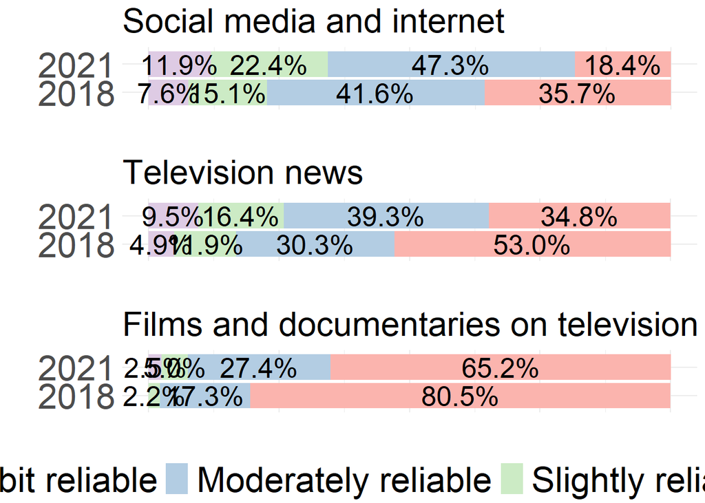

# Session information

R version 4.2.0 (2022-04-22 ucrt) Platform: x86_64-w64-mingw32/x64 (64-bit) Running under: Windows 10 x64 (build 22000)

Matrix products: default

locale: [1] LC_COLLATE=English_Cyprus.utf8 LC_CTYPE=English_Cyprus.utf8  
[3] LC_MONETARY=English_Cyprus.utf8 LC_NUMERIC=C  
[5] LC_TIME=English_Cyprus.utf8

attached base packages: [1] stats graphics grDevices utils datasets methods base

other attached packages: [1] viridis_0.6.2 viridisLite_0.4.0 hrbrthemes_0.8.0 ggstatsplot_0.9.4 [5] cowplot_1.1.1 ggpubr_0.4.0 haven_2.5.0 NADA_1.6-1.1  
[9] FSA_0.9.3 scales_1.2.0 reshape_0.8.9 texreg_1.38.6  
[13] janitor_2.1.0 Rcpp_1.0.8.3 eeptools_1.2.4 lubridate_1.8.0  
[17] forcats_0.5.1 stringr_1.4.0 dplyr_1.0.9 purrr_0.3.4  
[21] tidyverse_1.3.1 sjPlot_2.8.10 psych_2.2.3 readr_2.1.2  
[25] stargazer_5.2.3 compare_0.2-6 tableone_0.13.2 Hmisc_4.7-0  
[29] ggplot2_3.3.6 Formula_1.2-4 survival_3.3-1 lattice_0.20-45  
[33] tibble_3.1.7 knitr_1.39 tidyr_1.2.0 data.table_1.14.2 [37] dtplyr_1.2.1 plyr_1.8.7 readxl_1.4.0

loaded via a namespace (and not attached): [1] backports_1.4.1 systemfonts_1.0.4 sp_1.4-7  
[4] splines_4.2.0 TH.data_1.1-1 digest_0.6.29  
[7] htmltools_0.5.2 fansi_1.0.3 magrittr_2.0.3  
[10] checkmate_2.1.0 paletteer_1.4.0 cluster_2.1.3  
[13] tzdb_0.3.0 extrafont_0.18 modelr_0.1.8  
[16] extrafontdb_1.0 sandwich_3.0-1 jpeg_0.1-9  
[19] colorspace_2.0-3 rvest_1.0.2 mitools_2.4  
[22] xfun_0.30 crayon_1.5.1 jsonlite_1.8.0  
[25] lme4_1.1-29 zeallot_0.1.0 zoo_1.8-10  
[28] glue_1.6.2 gtable_0.3.0 emmeans_1.7.3  
[31] sjstats_0.18.1 sjmisc_2.8.9 statsExpressions_1.3.3 [34] car_3.0-13 Rttf2pt1_1.3.10 abind_1.4-5  
[37] mvtnorm_1.1-3 DBI_1.1.2 rstatix_0.7.0  
[40] ggeffects_1.1.2 xtable_1.8-4 performance_0.9.2  
[43] htmlTable_2.4.0 tmvnsim_1.0-2 proxy_0.4-26  
[46] foreign_0.8-82 survey_4.1-1 vcd_1.4-9  
[49] datawizard_0.5.0 htmlwidgets_1.5.4 httr_1.4.3  
[52] RColorBrewer_1.1-3 ellipsis_0.3.2 farver_2.1.0  
[55] pkgconfig_2.0.3 nnet_7.3-17 sass_0.4.1  
[58] dbplyr_2.1.1 utf8_1.2.2 labeling_0.4.2  
[61] tidyselect_1.1.2 rlang_1.0.2 effectsize_0.7.0.5  
[64] munsell_0.5.0 cellranger_1.1.0 tools_4.2.0  
[67] cli_3.3.0 generics_0.1.2 sjlabelled_1.2.0  
[70] broom_0.8.0 evaluate_0.15 fastmap_1.1.0  
[73] arm_1.12-2 yaml_2.3.5 rematch2_2.1.2  
[76] fs_1.5.2 nlme_3.1-157 xml2_1.3.3  
[79] correlation_0.8.2 compiler_4.2.0 rstudioapi_0.13  
[82] png_0.1-7 e1071_1.7-9 ggsignif_0.6.3  
[85] reprex_2.0.1 bslib_0.3.1 stringi_1.7.6  
[88] highr_0.9 parameters_0.18.2 gdtools_0.2.4  
[91] Matrix_1.4-1 nloptr_2.0.1 vctrs_0.4.1  
[94] pillar_1.7.0 lifecycle_1.0.1 lmtest_0.9-40  
[97] jquerylib_0.1.4 estimability_1.3 maptools_1.1-4  
[100] insight_0.18.2 patchwork_1.1.1 R6_2.5.1  
[103] latticeExtra_0.6-29 gridExtra_2.3 codetools_0.2-18  
[106] boot_1.3-28 MASS_7.3-57 assertthat_0.2.1  
[109] withr_2.5.0 mnormt_2.0.2 multcomp_1.4-19  
[112] bayestestR_0.12.1 parallel_4.2.0 hms_1.1.1  
[115] labelled_2.9.1 grid_4.2.0 rpart_4.1.16  
[118] class_7.3-20 coda_0.19-4 minqa_1.2.4  
[121] rmarkdown_2.14 snakecase_0.11.0 carData_3.0-5  
[124] base64enc_0.1-3